# Study of a Data Set applying Supervised Learning tools

## ROC Curve

ROC curve shows true positives vs false positives in relation with different thresholds:

y-axis = Sensitivity (TP) x-axis = Specificity (1-FP)

For the 2-class data set

```r
model <- lda(Type ~ ., data=datasetTrain_2c)
```

Lets now obtain the posterior probabilities (similar process as before)

```r
probability = predict(model, datasetTest_2c)$posterior
```

And also compute the ROC

```r
roc.lda <- roc(datasetTest_2c$Type,probability[,2])
auc(roc.lda)
```

```
## Area under the curve: 0.8962
```

Now that we have the AUC (Area Under the Curve) we can plot the ROC Curve graphically

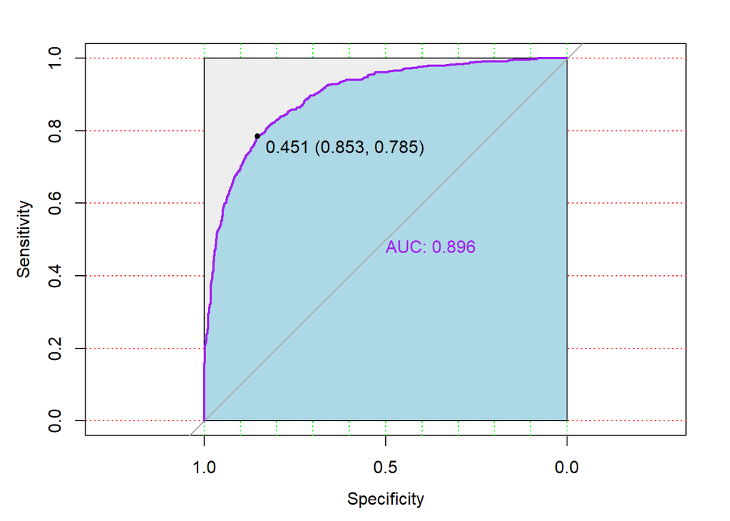

```r
plot.roc(datasetTest_2c$Type, probability[,2],col="purple", print.auc = TRUE,  auc.polygon=TRUE, grid=c(0.1, 0.2),
         grid.col=c("green", "red"), max.auc.polygon=TRUE,
         auc.polygon.col="lightblue", print.thres=TRUE)
```

When the AUC is bigger, the better, in our case our AUC is around 90%,so we can affirm the model is quite good. We can see that the area under the curve is big so we could say that our models are good. When the ROC curve goes more to the upper left corner, it means it is a perfect classification (AUC = 1). At the opposite side, the down right corner is a bad classification (AUC = 0) and the line at the middle would be if we try a model which guess randomly. In our case the ROC curve indicates that we have a quite good model because the AUC is big.

## The Benchmark

```r
library(gbm)
library(neuralnet)
```

In this case because we have many predictors, we will apply the penalized logistic regression

Again we will use our 2-class data set. Later on I will apply this same method for my multiclass data set (3-class data set)

```r
ctrl <- trainControl(method = "cv", number = 5,
                     classProbs = TRUE,
                     verboseIter=T)

# We have many predictors, hence use penalized logistic regression

lrFit <- train(Type ~ .,
               method = "glmnet",
               tuneGrid = expand.grid(alpha = seq(0, 1, 0.1), lambda = seq(0, .1, 0.02)),
               metric = "Kappa",
               data = auxtrain_2c,
               preProcess = c("center", "scale"),
               trControl = ctrl)
```

After training we can plot the lrFit

```r
print(lrFit)
```

```
## glmnet
##
## 9170 samples
##    9 predictor
##    2 classes: 'Average', 'Elite'
##
## Pre-processing: centered (9), scaled (9)
## Resampling: Cross-Validated (5 fold)
## Summary of sample sizes: 7336, 7336, 7336, 7336, 7336
## Resampling results across tuning parameters:
##
##   alpha  lambda  Accuracy   Kappa
##   0.0    0.00    0.8321701  0.6649607
##   0.0    0.02    0.8321701  0.6649607
##   0.0    0.04    0.8252999  0.6512902
##   0.0    0.06    0.8215921  0.6439451
##   0.0    0.08    0.8176663  0.6361708
##   0.0    0.10    0.8155943  0.6320852
##   0.1    0.00    0.9322792  0.8645928
##   0.1    0.02    0.8336968  0.6679951
##   0.1    0.04    0.8248637  0.6504357
##   0.1    0.06    0.8191930  0.6391653
##   0.1    0.08    0.8159215  0.6326944
##   0.1    0.10    0.8151581  0.6311947
##   0.2    0.00    0.9417666  0.8835377
##   0.2    0.02    0.8343511  0.6693019
##   0.2    0.04    0.8235551  0.6478239
##   0.2    0.06    0.8182116  0.6372394
##   0.2    0.08    0.8149400  0.6307400
##   0.2    0.10    0.8133043  0.6275064
##   0.3    0.00    0.9471101  0.8942109
##   0.3    0.02    0.8353326  0.6712633
##   0.3    0.04    0.8215921  0.6439200
##   0.3    0.06    0.8158124  0.6324469
##   0.3    0.08    0.8117775  0.6244262
##   0.3    0.10    0.8099237  0.6207633
##   0.4    0.00    0.9503817  0.9007527
##   0.4    0.02    0.8355507  0.6716992
##   0.4    0.04    0.8201745  0.6410922
##   0.4    0.06    0.8139586  0.6287645
```

[output cut: 26 more lines]

```
##   0.9    0.00    0.9559433  0.9118599
##   0.9    0.02    0.8377317  0.6760594
##   0.9    0.04    0.8117775  0.6243747
##   0.9    0.06    0.7979280  0.5966458
##   0.9    0.08    0.7919302  0.5847838
##   0.9    0.10    0.7845147  0.5701606
##   1.0    0.00    0.9563795  0.9127291
##   1.0    0.02    0.8434024  0.6873609
##   1.0    0.04    0.8094875  0.6197363
##   1.0    0.06    0.7966194  0.5940541
##   1.0    0.08    0.7886587  0.5783306
##   1.0    0.10    0.7789531  0.5592011
##
## Kappa was used to select the optimal model using the largest value.
## The final values used for the model were alpha = 1 and lambda = 0.
```

Make the predictions and the CM

```r
lrPred = predict(lrFit, auxtest_2c)
confusionMatrix(lrPred, auxtest_2c$Type)
```

```
## Confusion Matrix and Statistics
##
##           Reference
## Prediction Average Elite
##    Average    1078    46
##    Elite        41  1126
##
##                Accuracy : 0.962
##                  95% CI : (0.9534, 0.9695)
##     No Information Rate : 0.5116
##     P-Value [Acc > NIR] : <2e-16
##
##                   Kappa : 0.924
##
##  Mcnemar's Test P-Value : 0.668
##
##             Sensitivity : 0.9634
##             Specificity : 0.9608
##          Pos Pred Value : 0.9591
##          Neg Pred Value : 0.9649
##              Prevalence : 0.4884
##          Detection Rate : 0.4705
##    Detection Prevalence : 0.4906
##       Balanced Accuracy : 0.9621
##
##        'Positive' Class : Average
##
```

We obtained an accuracy of around 95% which is almost a perfect classification so this model are one of the best ones, as we can see the accuracy is close to 1 which is our main objective. We must pay attention in order to avoid a possible over fitting of the model.

## Variable Importance

Now we can plot the importance of each variable for the model and see which variables have the most impact

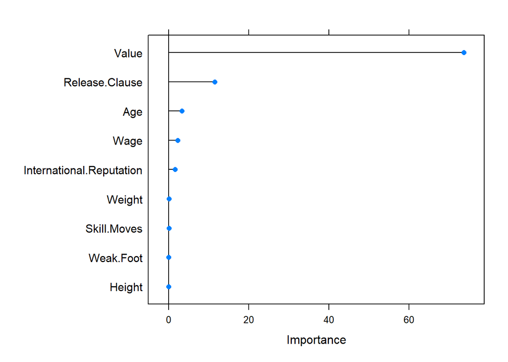

```r
lr_imp <- varImp(lrFit, scale = F)
plot(lr_imp, scales = list(y = list(cex = .95)))
```

We can clearly see that the variable Value is the most important in our model, followed by the Release Clause variable. The rest of the variables are less important comparted to Value.

## We can again plot the ROC Curve

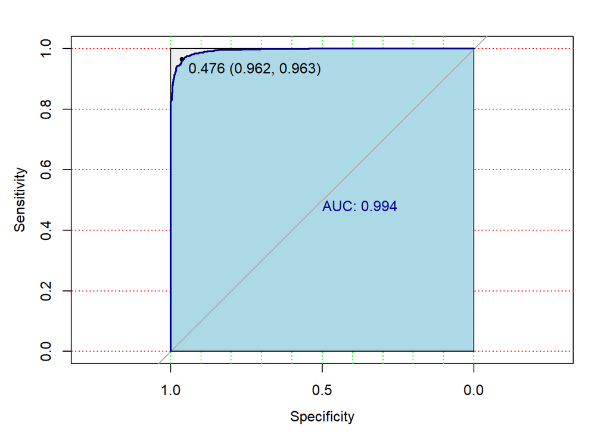

```r
library(pROC)
lrProb = predict(lrFit, auxtest_2c, type="prob")

plot.roc(auxtest_2c$Type, lrProb[,2],col="darkblue", print.auc = TRUE,  auc.polygon=TRUE, grid=c(0.1, 0.2),
         grid.col=c("green", "red"), max.auc.polygon=TRUE,
         auc.polygon.col="lightblue", print.thres=TRUE)
```

We obtained almost a perfect classification where the AUC is 0.99 because as I explained before, the AUC must be close to 1 in order to be a good model. A threshold around 0.4 is convenient for this case.

Additionally, we could plot the ROC Curve related to other important variables, for instance, we could choose International Reputation in order to see its ROC Curve.

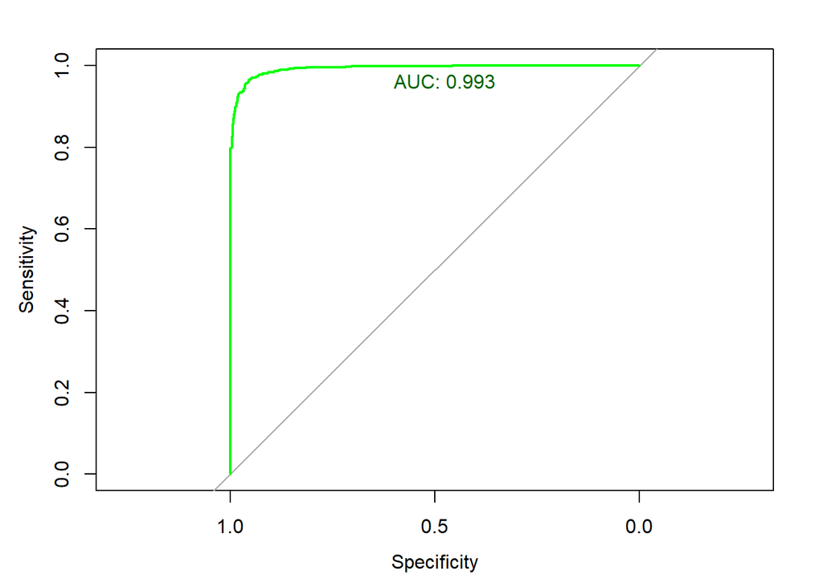

```r
plot.roc(auxtest_2c$Type[auxtest_2c$International.Reputation == 1], lrProb[auxtest_2c$International.Reputation == 1,2],print.auc = TRUE, col = "green", print.auc.col = "darkgreen",print.auc.y = 0.98, print.auc.x = 0.6)
```

We obtain a ROC curve similar to the previous one

```r
threshold = 0.4
lrProb = predict(lrFit, auxtest_2c, type="prob")
lrPred = rep("Average", nrow(auxtest_2c))
lrPred[which(lrProb[,2] > threshold)] = "Elite"
confusionMatrix(factor(lrPred), auxtest_2c$Type)
```

```
## Confusion Matrix and Statistics
##
##           Reference
## Prediction Average Elite
##    Average    1061    30
##    Elite        58  1142
##
##                Accuracy : 0.9616
##                  95% CI : (0.9529, 0.9691)
##     No Information Rate : 0.5116
##     P-Value [Acc > NIR] : < 2.2e-16
##
##                   Kappa : 0.9231
##
##  Mcnemar's Test P-Value : 0.003999
##
##             Sensitivity : 0.9482
##             Specificity : 0.9744
##          Pos Pred Value : 0.9725
##          Neg Pred Value : 0.9517
##              Prevalence : 0.4884
##          Detection Rate : 0.4631
##    Detection Prevalence : 0.4762
##       Balanced Accuracy : 0.9613
##
##        'Positive' Class : Average
##
```

Again, we obtain a 95% of accuracy which is great, as we can see in the different models, we are obtaining high accuracies so most of our models has been effective and effective.

## Cost-sensitive learning

As we can imagine, the errors will not have the same impact when predicting, that is why we must create a cost matrix in order to determine which mistakes or rights will have a biggest impact in our model.

For instance, it is less problematic to think a player from the elite belongs to the average compared to a player from the average class that is predicted to be in the elite class, because that would imply that player will probably earn a bigger wage and other aspects that would be a bigger mistake that in the inverse case. In the case it predicts that an elite player belongs to the average, that would also imply a cost (but less serious) because a potential player that could generate profits to the club cannot be recognized in order to sign him (or if is already in the club, retain him). Another option is to predict that a player is from the elite and actually been from the elite, which we will imply a higher wage and other aspects, and obviously, if a club needs to invest more money in order to retain a player, it is more risky than having an average player, because maybe if that players gets hurt or starts to have a bad daily routine (such as smoking, eating dunk food) the invest of money into that player will be loosed, for that reason I will add some cost if we predict it is an elite player and actually it is an elite player. Finally if a player is from the average and the model predicts it belongs to the average, we are fine so we do not need to addd any cost in there.

For that reason we must compute the unit cost taking into consideration the impact of the different possibilities.

In order to apply this the cost-sensitive learning method I must have a cost unit depending on the cost of predicting a true positive, false positive, true negative and false negative.

where: TN = True Negatives FP = False Positives FN = False Negatives TP = True Positives

In this way the cost matrix will be something similar to:

Unit cost is: 0*TN + 150xFP + 500xFN + 50xTP

As I said before, I will use as my cost.unit vector the one that the professor used in his case study assuming the cost will be equivalent. In this way I can show how the cost-sensitive learning could be applied to my work.

Firstly, we create the cost unit vector

```r
cost.unit <- c(0, 150, 500, 50)
```

## Cost of Naive classifier

```r
CM = confusionMatrix(factor(lrPred), auxtest_2c$Type)$table
cost = sum(as.vector(CM)*cost.unit)/sum(CM)
cost
```

```
## [1] 35.26844
```

We obtain the cost of the model, which we should compare this cost with other models in order to take into consideration which have the biggest cost (and then, would be a worse model).

## Cost-sensitive classifier (expert level)

```r
cost.i = matrix(NA, nrow = 100, ncol = 10)
# 20 replicates for training/testing sets for each of the 10 values of threshold

j <- 0
for (threshold in seq(0.05,0.5,0.05)){

  j <- j + 1
  cat(j)
  for(i in 1:100){

    # partition data intro training (75%) and testing sets (25%)
    d <- createDataPartition(auxtrain_2c$Type, p = 0.8, list = FALSE)
    # select training sample

    train <- aux_2c[d,]
    test  <- aux_2c[-d,]

    lrFit <- train(Type ~ ., data=auxtrain_2c, method = "glmnet",
                   tuneGrid = data.frame(alpha = 0.3, lambda = 0), preProcess = c("center", "scale"),
                   trControl = trainControl(method = "none", classProbs = TRUE))

    lrProb = predict(lrFit, auxtest_2c, type="prob")
    lrPred = rep("Average", nrow(auxtest_2c))
    lrPred[which(lrProb[,2] > threshold)] = "Elite"

    CM = confusionMatrix(factor(lrPred), auxtest_2c$Type)$table
    cost = sum(as.vector(CM)*cost.unit)/sum(CM)
    cost

    cost.i[i,j] <- cost

  }
}
```

```
## 12345678910
```

```r
#12345678910
```

This process is highly time consuming but also is true it is for expert level. Furthermore it will be useful in order to find the optimal threshold in order to compute the best model.

Now lets find the optimal threshold

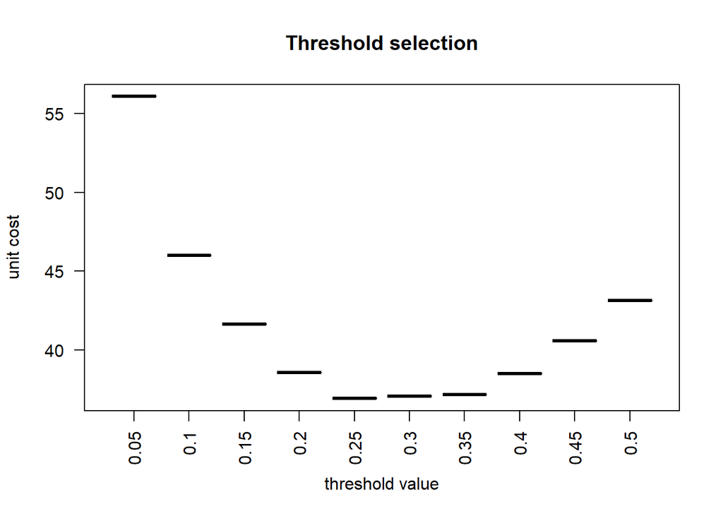

```r
# Threshold optimization:
boxplot(cost.i, main = "Threshold selection",
        ylab = "unit cost",
        xlab = "threshold value",
        names = seq(0.05,0.5,0.05),col="royalblue2",las=2)
```

```r
apply(cost.i, 2, median)
```

```
##  [1] 56.08904 46.00611 41.61938 38.54212 36.90528 37.03623 37.16718 38.47665
##  [9] 40.57180 43.12527
```

```r
threshold = 0.35
lrFit <- train(Type ~ ., data= auxtrain_2c, method = "glmnet",
               tuneGrid = data.frame(alpha = 0.3, lambda = 0), preProcess = c("center", "scale"),
               trControl = trainControl(method = "none", classProbs = TRUE))
lrProb = predict(lrFit, auxtest_2c, type="prob")
lrPred = rep("Average", nrow(auxtest_2c))
lrPred[which(lrProb[,2] > threshold)] = "Elite"
CM = confusionMatrix(factor(lrPred), auxtest_2c$Type)$table
cost = sum(as.vector(CM)*cost.unit)/sum(CM)
cost
```

```
## [1] 37.16718
```

## Risk learning

There are players which wage is higher than others. For instance, it is risky to pay a high wage to a player which do not belongs to the elite which cannot generates what he is getting paid, for that reason I will study in my risk learning the wages of players.

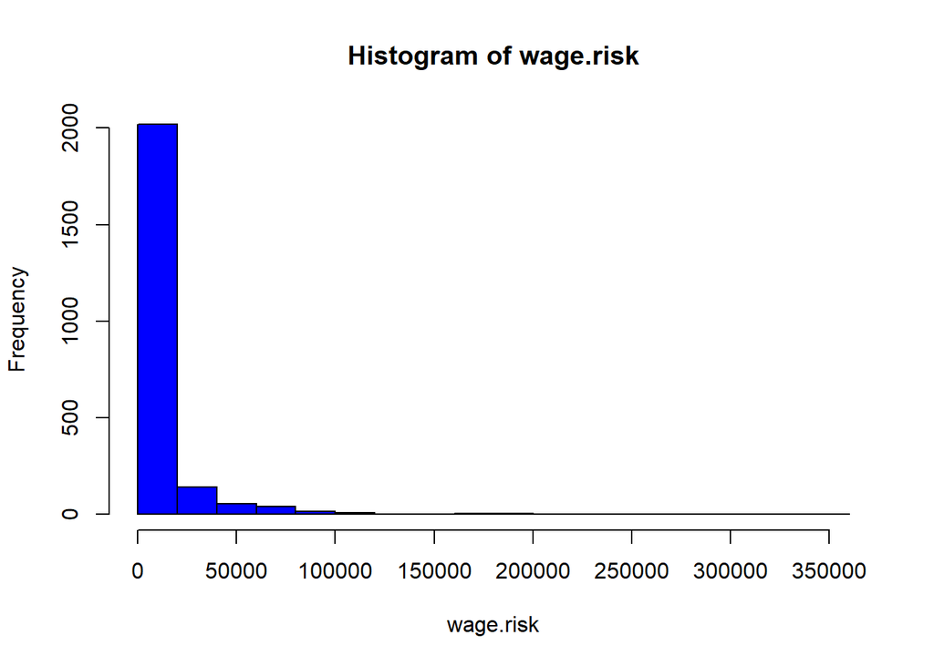

```r
wage.risk = auxtest_2c$Wage*lrProb[,2]
hist(wage.risk, col= "blue")
```

We should be worried about players with a wage higher than 10^5 € which starts to be a very high salary.

```r
sum(wage.risk>10^5)/length(wage.risk)
```

```
## [1] 0.009602794
```

Approximately 1% of footballers have this high wages

```r
sort.risk = sort(wage.risk,decreasing=T,index.return=T)
```

```r
# Most risky positions:
head(sort.risk$x)
```

```
## [1] 350000 270000 230000 230000 200000 200000
```

```r
# Most risky footballers:
head(sort.risk$ix)
```

```
## [1]   2   4  37 255  15 116
```

As we can see it shows the index of the footballers with the highest risk, this may be useful for clubs in order to study if they might reconsider the amount of money they are paying to their players.

# Machine Learning Tools

## Decision Trees

Firstly, a brief description of what is a decision tree. It is a flow-chart-like structure in which each internal node represents a test on a feature and it makes predictions based on how a previous set of questions were answered. It is important to mention about the hyper-parameters

Definitions: minsplit= minimum number of observations in a node before before a split cp= degree of complexity, the smaller the more branches maxdepth= maximum depth of any node of the final tree

```r
library(rpart)

# Here we decide the hyper-parameters that we will choose
control = rpart.control(minsplit = 30, maxdepth = 10, cp=0.01)
```

```r
model = Type ~.
dtFit <- rpart(model, data=auxtrain, method = "class", control = control)
summary(dtFit)
```

```
## Call:
## rpart(formula = model, data = auxtrain, method = "class", control = control)
##   n= 9170
##
##           CP nsplit rel error    xerror        xstd
## 1 0.41331087      0 1.0000000 1.0000000 0.007709782
## 2 0.28053917      1 0.5866891 0.5866891 0.007830487
## 3 0.04903117      2 0.3061500 0.3068239 0.006436706
## 4 0.04684078      3 0.2571188 0.2561078 0.005999943
## 5 0.02561078      4 0.2102780 0.2070767 0.005496777
## 6 0.01156978      5 0.1846672 0.1883741 0.005279191
## 7 0.01000000      8 0.1499579 0.1695029 0.005042491
##
## Variable importance
##                    Value           Release.Clause                     Wage
##                       34                       26                       17
##                      Age              Skill.Moves International.Reputation
##                       13                        5                        4
##                Weak.Foot
##                        2
##
## Node number 1: 9170 observations,    complexity param=0.4133109
##   predicted class=Silver  expected loss=0.6472192  P(node) =1
##     class counts:  3000  2935  3235
##    probabilities: 0.327 0.320 0.353
##   left son=2 (3876 obs) right son=3 (5294 obs)
##   Primary splits:
##       Value          < 537500  to the left,  improve=1871.8700, (0 missing)
##       Wage           < 4500    to the left,  improve=1667.2030, (0 missing)
##       Release.Clause < 1150000 to the left,  improve=1628.4630, (0 missing)
##       Age            < 21.5    to the left,  improve= 890.6689, (0 missing)
##       Skill.Moves    < 2.5     to the left,  improve= 559.2417, (0 missing)
##   Surrogate splits:
##       Release.Clause < 1150000 to the left,  agree=0.914, adj=0.797, (0 split)
##       Wage           < 1500    to the left,  agree=0.752, adj=0.412, (0 split)
##       Age            < 19.5    to the left,  agree=0.675, adj=0.231, (0 split)
##       Skill.Moves    < 2.5     to the left,  agree=0.652, adj=0.176, (0 split)
##       Weak.Foot      < 2.5     to the left,  agree=0.600, adj=0.054, (0 split)
##
## Node number 2: 3876 observations,    complexity param=0.04903117
```

[output cut: 151 more lines]

```
##
## Node number 29: 314 observations
##   predicted class=Silver  expected loss=0.2579618  P(node) =0.03424209
##     class counts:     0    81   233
##    probabilities: 0.000 0.258 0.742
##
## Node number 40: 261 observations
##   predicted class=Bronze  expected loss=0.2030651  P(node) =0.02846238
##     class counts:   208     0    53
##    probabilities: 0.797 0.000 0.203
##
## Node number 41: 124 observations
##   predicted class=Silver  expected loss=0.3225806  P(node) =0.01352236
##     class counts:    13    27    84
##    probabilities: 0.105 0.218 0.677
```

For each node in the tree, the number of examples reaching the decision point is listed

But it is better if we plot and visualize the computed decision tree.

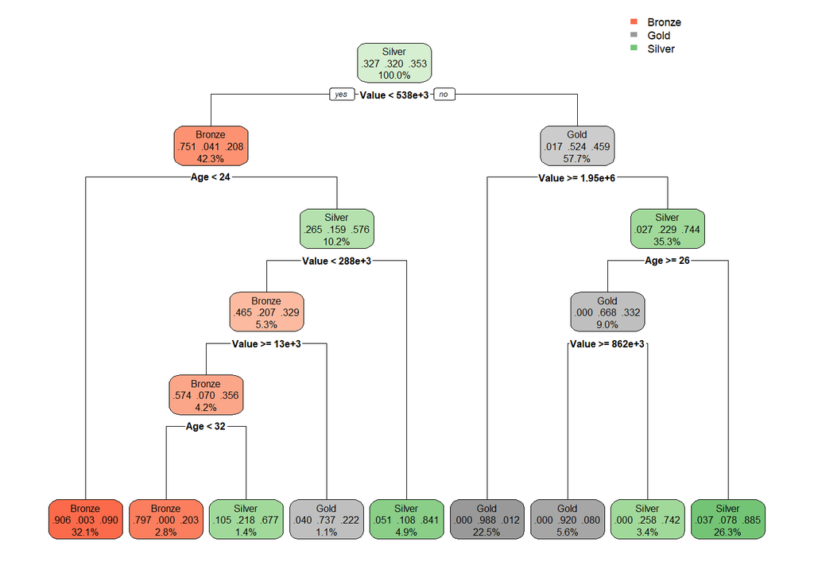

```r
library(rpart.plot)
rpart.plot(dtFit, digits=3)
```

It can be appreciated that each node shows the predict class, the predicted probability of each class and the percentage of observations in each node. Also it is important to mention that due to pruning other nodes have been removed. In our case, it took into consideration variables such as Value or Age in order to predict the overall of the player.

In the case we are interested in computing a FULL decision tree, we must set the complexity paremter “cp” to (or close to it) and also set the minimum number of observations in a node needed to split to the smallest value of 2.

So we might modify the hyper parameters in order to see what would happen.

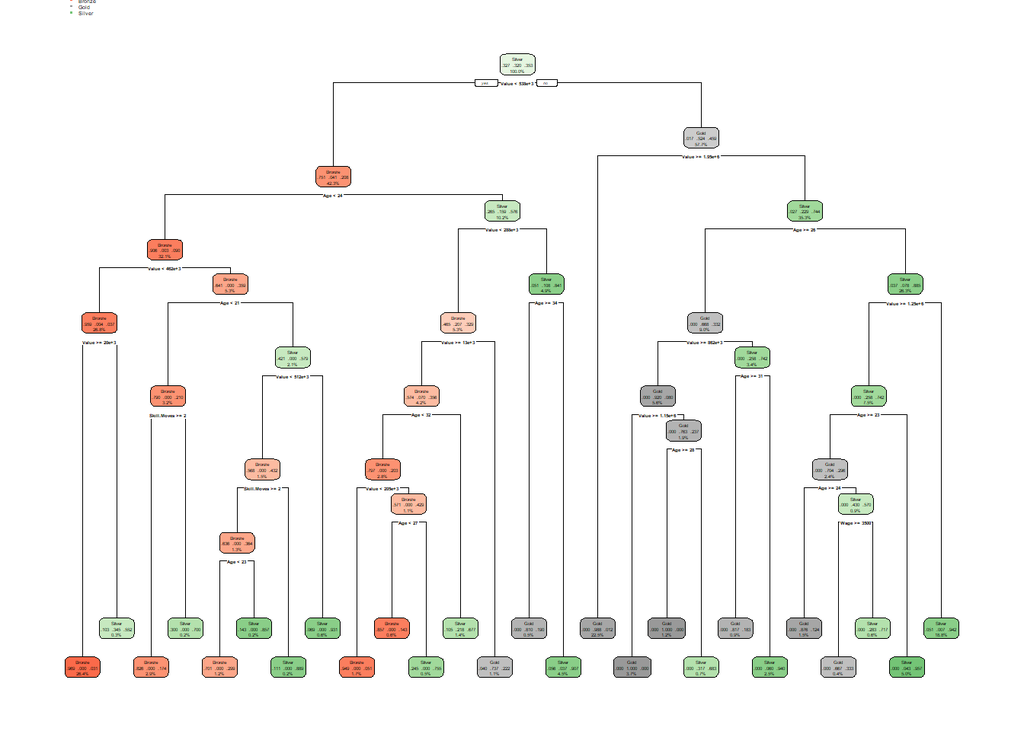

```r
control = rpart.control(minsplit = 40, maxdepth = 12, cp=0.001)
dtFit <- rpart(model, data=auxtrain, method = "class", control = control)

rpart.plot(dtFit, digits = 3)
```

And this is the way to obtain our full decision tree, however it is quite PC-demanding and even there could be some over plotting between the nodes.

If we work with our bi variable classification data set and plot its decision tree. Also we might again tune the hyper parameters in order to see which one would be the optimal.

```r
control = rpart.control(minsplit = 25, maxdepth = 11, cp=0.01)
model = Type ~.
dtFit <- rpart(model, data=auxtrain_2c, method = "class", control = control)
summary(dtFit)
```

```
## Call:
## rpart(formula = model, data = auxtrain_2c, method = "class",
##     control = control)
##   n= 9170
##
##           CP nsplit  rel error     xerror        xstd
## 1 0.75714286      0 1.00000000 1.00000000 0.010684710
## 2 0.06774554      1 0.24285714 0.24285714 0.006912119
## 3 0.01696429      3 0.10736607 0.10781250 0.004774697
## 4 0.01000000      4 0.09040179 0.09084821 0.004402110
##
## Variable importance
##                    Value           Release.Clause                     Wage
##                       31                       26                       16
##                      Age              Skill.Moves International.Reputation
##                       13                        9                        4
##
## Node number 1: 9170 observations,    complexity param=0.7571429
##   predicted class=Elite    expected loss=0.4885496  P(node) =1
##     class counts:  4480  4690
##    probabilities: 0.489 0.511
##   left son=2 (5370 obs) right son=3 (3800 obs)
##   Primary splits:
##       Value          < 912500  to the left,  improve=2776.0450, (0 missing)
##       Release.Clause < 1550000 to the left,  improve=2367.1910, (0 missing)
##       Wage           < 2500    to the left,  improve=1527.9560, (0 missing)
##       Age            < 21.5    to the left,  improve=1232.2770, (0 missing)
##       Skill.Moves    < 2.5     to the left,  improve= 705.4896, (0 missing)
##   Surrogate splits:
##       Release.Clause           < 1750000 to the left,  agree=0.919, adj=0.803, (0 split)
##       Wage                     < 3500    to the left,  agree=0.813, adj=0.548, (0 split)
##       Skill.Moves              < 2.5     to the left,  agree=0.716, adj=0.314, (0 split)
##       Age                      < 22.5    to the left,  agree=0.649, adj=0.153, (0 split)
##       International.Reputation < 1.5     to the left,  agree=0.640, adj=0.131, (0 split)
##
## Node number 2: 5370 observations,    complexity param=0.06774554
##   predicted class=Average  expected loss=0.1841713  P(node) =0.5856052
##     class counts:  4381   989
##    probabilities: 0.816 0.184
##   left son=4 (3890 obs) right son=5 (1480 obs)
```

[output cut: 57 more lines]

```
##
## Node number 11: 863 observations
##   predicted class=Elite    expected loss=0.1483198  P(node) =0.09411123
##     class counts:   128   735
##    probabilities: 0.148 0.852
##
## Node number 20: 465 observations
##   predicted class=Average  expected loss=0.08172043  P(node) =0.05070883
##     class counts:   427    38
##    probabilities: 0.918 0.082
##
## Node number 21: 152 observations
##   predicted class=Elite    expected loss=0.25  P(node) =0.01657579
##     class counts:    38   114
##    probabilities: 0.250 0.750
```

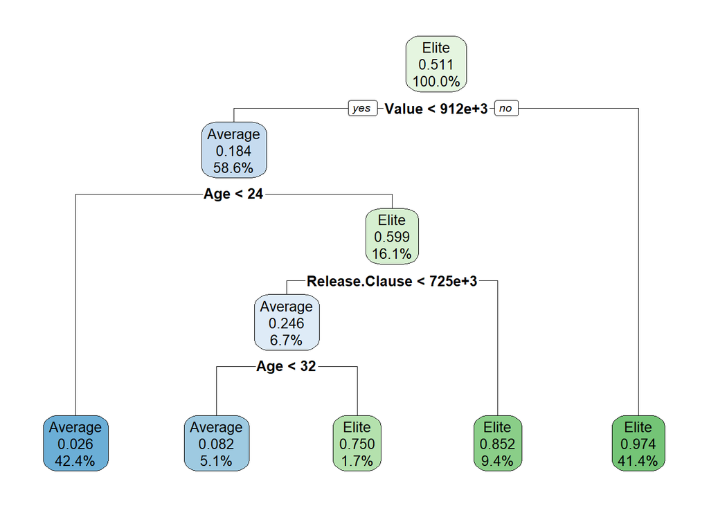

```r
rpart.plot(dtFit, digits=3)
```

And if we are interested in the full decision tree..

```r
control = rpart.control(minsplit = 41, maxdepth = 12, cp=0.001)
dtFit <- rpart(model, data=auxtrain_2c, method = "class", control = control)
summary(dtFit)
```

```
## Call:
## rpart(formula = model, data = auxtrain_2c, method = "class",
##     control = control)
##   n= 9170
##
##             CP nsplit  rel error     xerror        xstd
## 1  0.757142857      0 1.00000000 1.00000000 0.010684710
## 2  0.067745536      1 0.24285714 0.24620536 0.006953142
## 3  0.016964286      3 0.10736607 0.10825893 0.004784021
## 4  0.005468750      4 0.09040179 0.09174107 0.004422680
## 5  0.003571429      6 0.07946429 0.08370536 0.004233220
## 6  0.002901786      8 0.07232143 0.08080357 0.004162270
## 7  0.002455357      9 0.06941964 0.07544643 0.004027404
## 8  0.002008929     10 0.06696429 0.07120536 0.003916777
## 9  0.001785714     12 0.06294643 0.06919643 0.003863092
## 10 0.001190476     14 0.05937500 0.06428571 0.003728112
## 11 0.001000000     17 0.05580357 0.06160714 0.003652081
##
## Variable importance
##                    Value           Release.Clause                     Wage
##                       31                       26                       16
##                      Age              Skill.Moves International.Reputation
##                       14                        9                        4
##
## Node number 1: 9170 observations,    complexity param=0.7571429
##   predicted class=Elite    expected loss=0.4885496  P(node) =1
##     class counts:  4480  4690
##    probabilities: 0.489 0.511
##   left son=2 (5370 obs) right son=3 (3800 obs)
##   Primary splits:
##       Value          < 912500  to the left,  improve=2776.0450, (0 missing)
##       Release.Clause < 1550000 to the left,  improve=2367.1910, (0 missing)
##       Wage           < 2500    to the left,  improve=1527.9560, (0 missing)
##       Age            < 21.5    to the left,  improve=1232.2770, (0 missing)
##       Skill.Moves    < 2.5     to the left,  improve= 705.4896, (0 missing)
##   Surrogate splits:
##       Release.Clause           < 1750000 to the left,  agree=0.919, adj=0.803, (0 split)
##       Wage                     < 3500    to the left,  agree=0.813, adj=0.548, (0 split)
##       Skill.Moves              < 2.5     to the left,  agree=0.716, adj=0.314, (0 split)
##       Age                      < 22.5    to the left,  agree=0.649, adj=0.153, (0 split)
```

[output cut: 343 more lines]

```
##
## Node number 181: 43 observations
##   predicted class=Elite    expected loss=0.04651163  P(node) =0.004689204
##     class counts:     2    41
##    probabilities: 0.047 0.953
##
## Node number 360: 22 observations
##   predicted class=Average  expected loss=0.1363636  P(node) =0.002399128
##     class counts:    19     3
##    probabilities: 0.864 0.136
##
## Node number 361: 54 observations
##   predicted class=Elite    expected loss=0.2407407  P(node) =0.005888768
##     class counts:    13    41
##    probabilities: 0.241 0.759
```

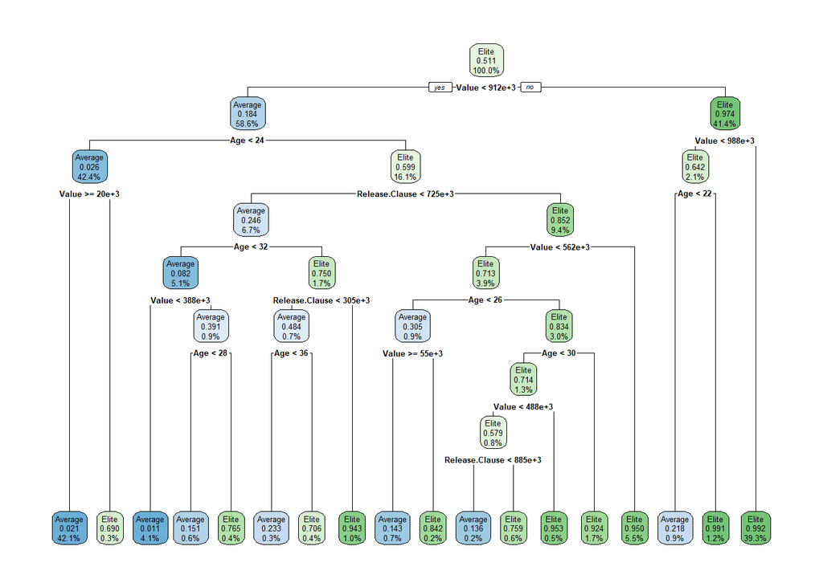

```r
rpart.plot(dtFit, digits = 3)
```

Now lets do the predictions to plot the confusion matrix in our 2-class categorical variable data set.

```r
dtPred <- predict(dtFit, auxtest_2c, type = "class")
dtProb <- predict(dtFit, auxtest_2c, type = "prob")
threshold = 0.2 # A threshold of 0.2 its acceptable
dtPred = rep("Average", nrow(auxtest_2c))
dtPred[which(dtProb[,2] > threshold)] = "Elite"
CM = confusionMatrix(factor(dtPred), auxtest_2c$Type)$table
CM
```

```
##           Reference
## Prediction Average Elite
##    Average    1067    25
##    Elite        52  1147
```

```r
confusionMatrix(factor(dtPred), auxtest_2c$Type)$overall[1]
```

```
##  Accuracy
## 0.9663902
```

```r
cost = sum(as.vector(CM)*cost.unit)/sum(CM)
cost
```

```
## [1] 33.8935
```

And again, we obtain an accuracy around 97% and we also obtained the cost, we can see that te cost in this case has decreased compare to the previous model, so we can affirm this model is way better.

## Using Caret

For our multiclass data set:

```r
library(caret)

caret.fit <- train(model,
                   data = auxtrain,
                   method = "rpart",
                   control=rpart.control(minsplit = 40, maxdepth = 12),
                   trControl = trainControl(method = "cv", number = 5),
                   tuneLength=10)
caret.fit
```

```
## CART
##
## 9170 samples
##    9 predictor
##    3 classes: 'Bronze', 'Gold', 'Silver'
##
## No pre-processing
## Resampling: Cross-Validated (5 fold)
## Summary of sample sizes: 7336, 7336, 7336, 7336, 7336
## Resampling results across tuning parameters:
##
##   cp           Accuracy   Kappa
##   0.002611626  0.9219193  0.8828492
##   0.004380792  0.9162486  0.8743592
##   0.007666386  0.9095965  0.8643037
##   0.008761584  0.9000000  0.8497713
##   0.011569784  0.8852781  0.8275035
##   0.025610783  0.8671756  0.8004744
##   0.046840775  0.8342421  0.7505500
##   0.049031171  0.8342421  0.7505500
##   0.280539174  0.7269357  0.5934904
##   0.413310868  0.4583424  0.1734900
##
## Accuracy was used to select the optimal model using the largest value.
## The final value used for the model was cp = 0.002611626.
```

And in order to visualize it.

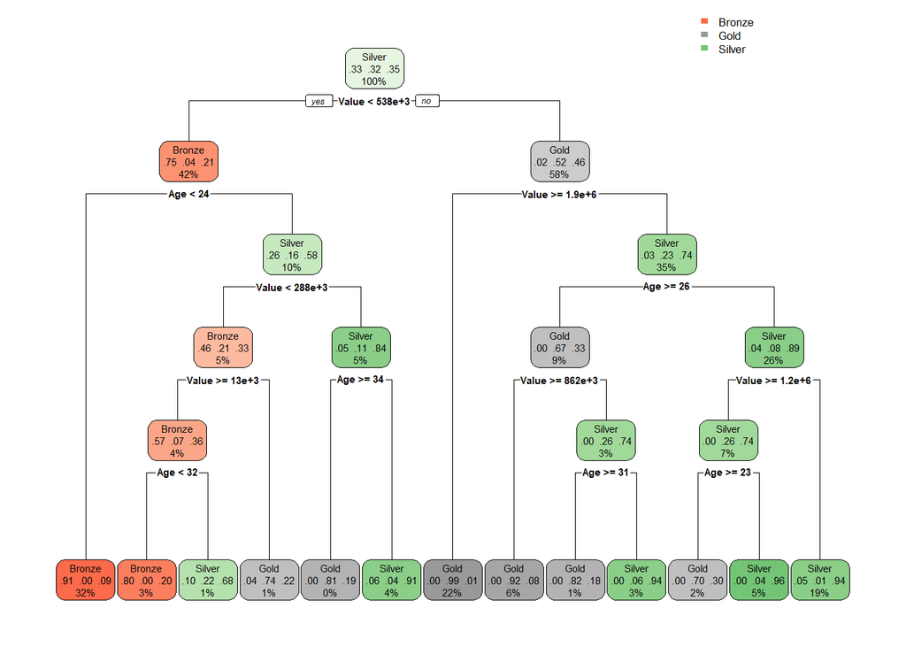

```r
rpart.plot(caret.fit$finalModel)
```

And for our bi variable classification data set and in order to compute the CM…

```r
caret.fit <- train(model,
                   data = auxtrain_2c,
                   method = "rpart",
                   control=rpart.control(minsplit = 40, maxdepth = 12),
                   trControl = trainControl(method = "cv", number = 5),
                   tuneLength=10)
caret.fit
```

```
## CART
##
## 9170 samples
##    9 predictor
##    2 classes: 'Average', 'Elite'
##
## No pre-processing
## Resampling: Cross-Validated (5 fold)
## Summary of sample sizes: 7336, 7336, 7336, 7336, 7336
## Resampling results across tuning parameters:
##
##   cp           Accuracy   Kappa
##   0.001339286  0.9673937  0.9347596
##   0.001450893  0.9673937  0.9347596
##   0.002008929  0.9640131  0.9279876
##   0.002455357  0.9624864  0.9249409
##   0.002901786  0.9613959  0.9227646
##   0.003571429  0.9595420  0.9190379
##   0.005468750  0.9570338  0.9139939
##   0.016964286  0.9488550  0.8976492
##   0.067745536  0.9070883  0.8147309
##   0.757142857  0.6579062  0.3024654
##
## Accuracy was used to select the optimal model using the largest value.
## The final value used for the model was cp = 0.001450893.
```

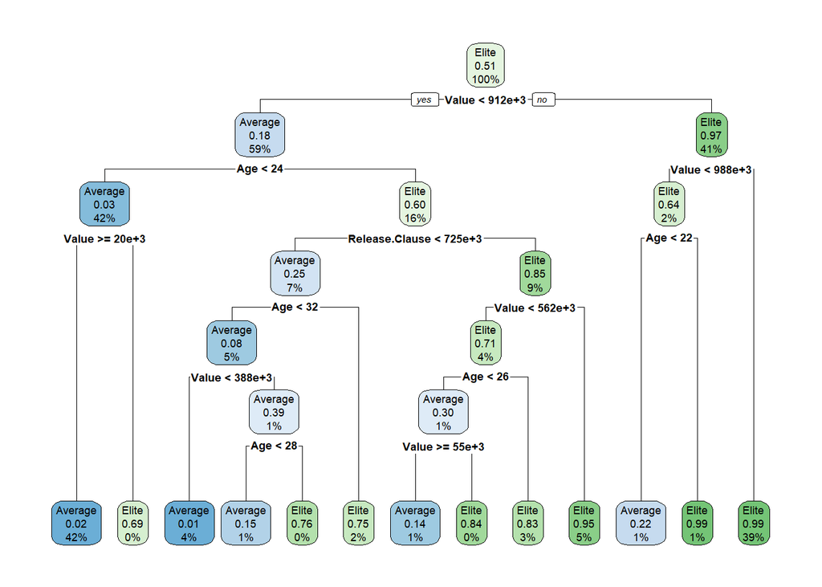

```r
rpart.plot(caret.fit$finalModel)
```

Predictions:

```r
dtProb <- predict(caret.fit, auxtest_2c, type = "prob")
threshold = 0.2
dtPred = rep("Average", nrow(auxtest_2c))
dtPred[which(dtProb[,2] > threshold)] = "Elite"
CM = confusionMatrix(factor(dtPred), auxtest_2c$Type)$table
CM
```

```
##           Reference
## Prediction Average Elite
##    Average    1061    25
##    Elite        58  1147
```

```r
confusionMatrix(factor(dtPred), auxtest_2c$Type)$overall[1]
```

```
##  Accuracy
## 0.9637713
```

```r
cost = sum(as.vector(CM)*cost.unit)/sum(CM)
cost
```

```
## [1] 34.28634
```

We obtain a very similar accuracy and cost compared to the previous model not using Caret approach so they are basically equivalent methods.

## Random Forest

A brief description of random forests would be an algorithm consisting of many decision trees, which we had already done it previously. Definitions: mtry: number of variables randomly sampled as candidates at each split ntree: number of trees to grow cutoff: cutoff probabilities in majority vote

We start by computing the random forest training model

```r
rf.train <- randomForest(Type ~., data= auxtrain,ntree=200,mtry=9,cutoff=c(0.33,0.33, 0.33),importance=TRUE, do.trace=T)
```

```
## ntree      OOB      1      2      3
##     1:   8.19%  7.36%  5.06% 11.80%
##     2:   8.38%  6.69%  5.77% 12.26%
##     3:   8.42%  6.71%  5.57% 12.56%
##     4:   8.29%  6.75%  5.34% 12.36%
##     5:   8.06%  6.85%  4.82% 12.08%
##     6:   7.80%  6.51%  4.93% 11.62%
##     7:   7.47%  6.29%  4.70% 11.08%
##     8:   7.19%  5.82%  4.34% 11.05%
##     9:   7.13%  6.03%  4.26% 10.76%
##    10:   7.00%  6.00%  4.34% 10.35%
##    11:   7.02%  6.06%  4.35% 10.33%
##    12:   6.84%  5.85%  4.28% 10.10%
##    13:   6.88%  5.64%  4.61% 10.08%
##    14:   6.75%  5.51%  4.44% 10.00%
```

[output cut: 186 more lines]

Predict and compute the Confusion Matrix

```r
rf.pred <- predict(rf.train, newdata=auxtest)
confusionMatrix(rf.pred, auxtest$Type)
```

```
## Confusion Matrix and Statistics
##
##           Reference
## Prediction Bronze Gold Silver
##     Bronze    706    0     46
##     Gold        3  709     26
##     Silver     41   24    736
##
## Overall Statistics
##
##                Accuracy : 0.9389
##                  95% CI : (0.9283, 0.9484)
##     No Information Rate : 0.3527
##     P-Value [Acc > NIR] : <2e-16
##
##                   Kappa : 0.9083
##
##  Mcnemar's Test P-Value : 0.3384
##
## Statistics by Class:
##
##                      Class: Bronze Class: Gold Class: Silver
## Sensitivity                 0.9413      0.9673        0.9109
## Specificity                 0.9701      0.9814        0.9562
## Pos Pred Value              0.9388      0.9607        0.9189
## Neg Pred Value              0.9714      0.9845        0.9517
## Prevalence                  0.3274      0.3199        0.3527
## Detection Rate              0.3082      0.3095        0.3213
## Detection Prevalence        0.3282      0.3221        0.3496
## Balanced Accuracy           0.9557      0.9743        0.9335
```

And for the bivariable classification

```r
rf.train <- randomForest(Type ~., data= auxtrain_2c,ntree=200,mtry=8,cutoff=c(0.75,0.25),importance=TRUE, do.trace=T)
```

```
## ntree      OOB      1      2
##     1:   3.24%  3.55%  2.93%
##     2:   3.41%  3.96%  2.86%
##     3:   3.39%  4.35%  2.45%
##     4:   3.54%  4.66%  2.46%
##     5:   3.55%  4.95%  2.22%
##     6:   3.63%  5.26%  2.07%
##     7:   3.70%  5.49%  1.98%
##     8:   3.59%  5.38%  1.88%
##     9:   3.58%  5.41%  1.84%
##    10:   3.67%  5.54%  1.87%
##    11:   3.56%  5.38%  1.82%
##    12:   3.50%  5.26%  1.82%
##    13:   3.46%  5.25%  1.75%
##    14:   3.45%  5.27%  1.71%
```

[output cut: 186 more lines]

```r
rf.pred <- predict(rf.train, newdata=auxtest_2c)
confusionMatrix(rf.pred, auxtest_2c$Type)
```

```
## Confusion Matrix and Statistics
##
##           Reference
## Prediction Average Elite
##    Average    1063    12
##    Elite        56  1160
##
##                Accuracy : 0.9703
##                  95% CI : (0.9625, 0.9769)
##     No Information Rate : 0.5116
##     P-Value [Acc > NIR] : < 2.2e-16
##
##                   Kappa : 0.9406
##
##  Mcnemar's Test P-Value : 1.843e-07
##
##             Sensitivity : 0.9500
##             Specificity : 0.9898
##          Pos Pred Value : 0.9888
##          Neg Pred Value : 0.9539
##              Prevalence : 0.4884
##          Detection Rate : 0.4640
##    Detection Prevalence : 0.4692
##       Balanced Accuracy : 0.9699
##
##        'Positive' Class : Average
##
```

Now it would be interesting to optimize the hyper-parameters in order to find even a better model, in order to do that:

We must define a specific function called CostFunction:

```r
CostFunction <- function(data, lev = NULL, model = NULL)
{
  y.pred = data$pred
  y.true = data$obs
  CM = confusionMatrix(y.pred, y.true)$table
  out = sum(as.vector(CM)*cost.unit)/sum(CM)
  names(out) <- c("CostFunction")
  out
}
```

Now if we include this function in the Caret Control:

```r
ctrl <- trainControl(method = "cv", number = 5,
                     classProbs = TRUE,
                     summaryFunction = CostFunction,
                     verboseIter=T)
```

For instance, this would be the cost with the previous prediction

```r
CostFunction(data = data.frame(pred  = rf.pred, obs = auxtest_2c$Type))
```

```
## CostFunction
##     31.60192
```

Now we must train a Random Forest with a specific metric using Caret

```r
rf.train <- train(Type ~.,
                  method = "rf",
                  data = auxtrain_2c,
                  preProcess = c("center", "scale"),
                  ntree = 200,
                  cutoff=c(0.7,0.3),
                  tuneGrid = expand.grid(mtry=c(4,5,6)),
                  metric = "CostFunction",
                  maximize = F,
                  trControl = ctrl)
```

And now for the variable importance

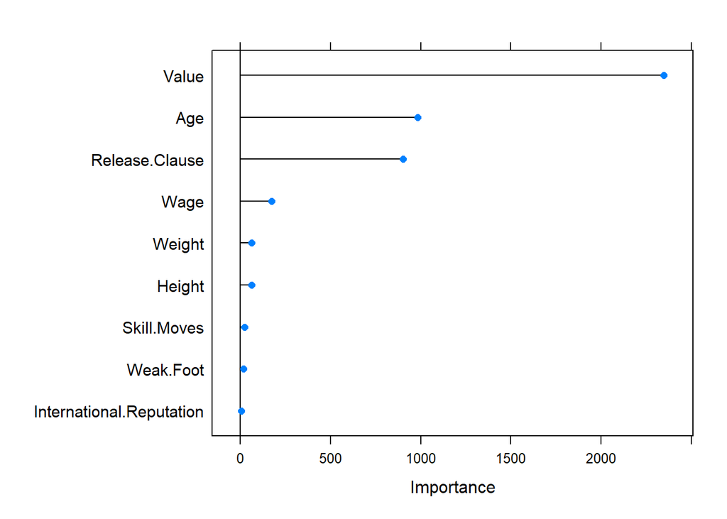

```r
rf_imp <- varImp(rf.train, scale = F)
plot(rf_imp, scales = list(y = list(cex = .95)))
```

We obtain that there are 3 variables which are the most importants, which are in first place the Value, secondly the age of the player and in third place the release clause. The other variables are much less important compared to those 3 (especially Value, which is super important), so we could say that our model relies in an important part from those three variables, especially in the first one.

```r
rfPred = predict(rf.train, newdata=auxtest_2c)
CM = confusionMatrix(factor(rfPred), auxtest_2c$Type)$table
CM
```

```
##           Reference
## Prediction Average Elite
##    Average    1074    16
##    Elite        45  1156
```

```r
confusionMatrix(factor(rfPred), auxtest_2c$Type)$overall[1]
```

```
##  Accuracy
## 0.9733741
```

```r
cost = sum(as.vector(CM)*cost.unit)/sum(CM)
cost
```

```
## [1] 31.66739
```

In this time, we obtain an accuracy of 97% which is almost a perfect classification and a cost of 31 which is lower than the previous models, so at the moment random forests are probably one of the best tools to apply. However, it is important to mention that takes time in order to execute this method.

It is important to mention that sometimes the hyper-parameters in the Machine Learning tools are less important that the threshold in the Bayes rule (however both of them are essential in order to obtain good models and predictions)

```r
threshold = 0.3
rfProb = predict(rf.train, newdata=auxtest_2c, type="prob")
rfPred = rep("Average", nrow(auxtest_2c))
rfPred[which(rfProb[,2] > threshold)] = "Elite"
CM = confusionMatrix(factor(rfPred), auxtest_2c$Type)$table
CM
```

```
##           Reference
## Prediction Average Elite
##    Average    1075    16
##    Elite        44  1156
```

```r
cost = sum(as.vector(CM)*cost.unit)/sum(CM)
cost
```

```
## [1] 31.60192
```

We obtain a similar output as before.

## Gradient Boosting

We will use our bivariable classification data set

```r
GBM.train <- gbm(ifelse(auxtrain_2c$Type=="Average",0,1) ~., data=auxtrain_2c, distribution= "bernoulli",n.trees=250,shrinkage = 0.01,interaction.depth=2,n.minobsinnode = 8)
```

Lets compute the predictions

```r
threshold = 0.2
gbmProb = predict(GBM.train, newdata=auxtest_2c, n.trees=250, type="response")
gbmPred = rep("Average", nrow(auxtest_2c))
gbmPred[which(gbmProb > threshold)] = "Elite"
CM = confusionMatrix(factor(gbmPred), auxtest_2c$Type)$table
CM
```

```
##           Reference
## Prediction Average Elite
##    Average     897     4
##    Elite       222  1168
```

```r
confusionMatrix(factor(gbmPred), auxtest_2c$Type)$overall[1]
```

```
##  Accuracy
## 0.9013531
```

```r
cost = sum(as.vector(CM)*cost.unit)/sum(CM)
cost
```

```
## [1] 40.89917
```

Maybe we could try now the xgboost with Caret, so firstly we will define a grid for the hyper-parameters. However this method is extremely demanding for the PC, so that is an important disadvantage.

```r
xgb_grid = expand.grid(
  nrounds = c(500,1000),
  eta = c(0.01, 0.001), # c(0.01,0.05,0.1)
  max_depth = c(2, 4, 6),
  gamma = 1,
  colsample_bytree = c(0.2, 0.4),
  min_child_weight = c(1,5),
  subsample = 1
)
```

Now its time to train

```r
xgb.train = train(Type ~ .,  data=auxtrain_2c,
                  trControl = ctrl,
                  metric="CostFunction",
                  maximize = F,
                  tuneGrid = xgb_grid,
                  preProcess = c("center", "scale"),
                  method = "xgbTree"
)
```

[output not shown]

[output cut: 186 more lines]

[output not shown]

Variable importance

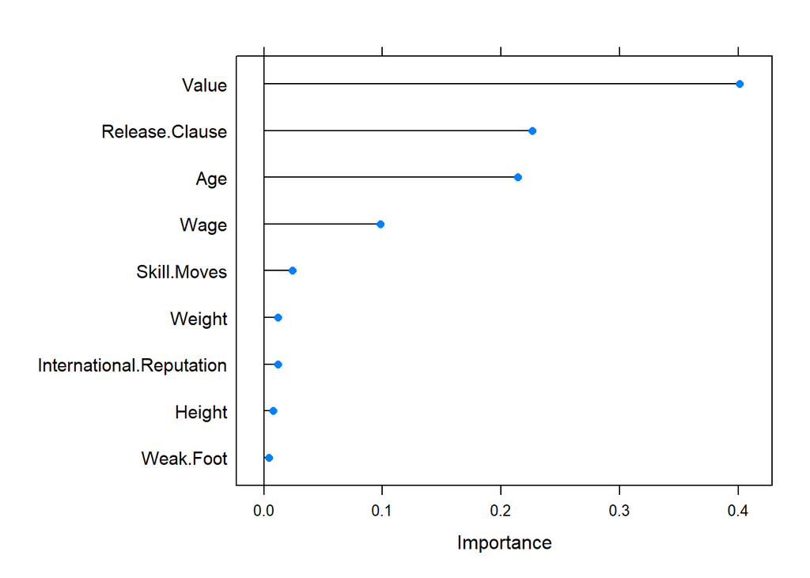

```r
xgb_imp <- varImp(xgb.train, scale = F)
plot(xgb_imp, scales = list(y = list(cex = .95)))
```

Once again, we can see that the variables Value, Release clause and age are the most important. However, it is true that now others variables such as Wage or Skill moves are not so insignificant as before, and now value variable has decreased its importance. This might be interesting because our model now it is not relying almost completely in just one variable.

Prediction and cost

```r
threshold = 0.2
xgbProb = predict(xgb.train, newdata=auxtest_2c, type="prob")
xgbPred = rep("Average", nrow(auxtest_2c))
xgbPred[which(xgbProb[,2] > threshold)] = "Elite"
CM = confusionMatrix(factor(xgbPred), auxtest_2c$Type)$table
CM
```

```
##           Reference
## Prediction Average Elite
##    Average    1047    11
##    Elite        72  1161
```

```r
confusionMatrix(factor(xgbPred), auxtest_2c$Type)$overall[1]
```

```
##  Accuracy
## 0.9637713
```

```r
cost = sum(as.vector(CM)*cost.unit)/sum(CM)
cost
```

```
## [1] 32.45308
```

It is important to mention that our accuracy has increased to almost 0.96 so we can see that despite it is a very demanding method, we obtained a high accuracy and a good model. Also our cost is lower that with the gbm model, it is still worse that other models such as the random forest model but is still an excellent model.

## Subsampling Techniques

```r
ctrl$sampling <- "up"

rf.train <- train(Type ~.,
                  method = "rf",
                  data = auxtrain_2c,
                  preProcess = c("center", "scale"),
                  ntree = 200,
                  cutoff=c(0.7,0.3),
                  tuneGrid = expand.grid(mtry=c(4,5,6)),
                  importance=TRUE,
                  metric = "CostFunction",
                  maximize = F,
                  trControl = ctrl)
```

Prediction and cost

```r
threshold = 0.2
rfProb = predict(rf.train, newdata=auxtest_2c, type="prob")
rfPred = rep("Average", nrow(auxtest_2c))
rfPred[which(rfProb[,2] > threshold)] = "Elite"
CM = confusionMatrix(factor(rfPred), auxtest_2c$Type)$table
confusionMatrix(factor(rfPred), auxtest_2c$Type)$overall[1]
```

```
##  Accuracy
## 0.9668267
```

```r
cost = sum(as.vector(CM)*cost.unit)/sum(CM)
cost
```

```
## [1] 31.99476
```

We obtained an accuracy of almost 0.97 and a cost of almost 32, this model is also almost a perfect classification and have the same characteristics as the random forest model, so this one is also one of the best models that we have created at the moment.

## Basic Ensembles

Ensemble learning is based on combining the best classifiers and form a meta-classifier

We will start by creating an ensemble for classification with the mode function for our bivariable classification data set.

```r
mode <- function(v) {
  uniqv <- unique(v)
  uniqv[which.max(tabulate(match(v, uniqv)))]
}
```

Now lets see the accuracy an the CM

```r
ensemble.pred = apply(data.frame(lrPred,xgbPred, lrProb), 1, mode)
CM = confusionMatrix(factor(ensemble.pred), auxtest_2c$Type)$table
CM
```

```
##           Reference
## Prediction Average Elite
##    Average    1029    29
##    Elite        90  1143
```

```r
confusionMatrix(factor(ensemble.pred), auxtest_2c$Type)$overall[1]
```

```
##  Accuracy
## 0.9480576
```

```r
cost = sum(as.vector(CM)*cost.unit)/sum(CM)
cost
```

```
## [1] 37.16718
```

Once again, by just computing the confusion matrix we could notice that our model had very few mistakes and also by computing the accuracy we saw that it is around 95% of accuracy and the cost is around 37, it is not a bad model but compared with the previous ones (such as subsampling or random forest) it is not the best one either. Furthermore, ensemble models works better after adding more, better and diverse predictions. Also we can see that our cost remains similar.

## Conclusion about Classification tools

We had done most of the classification tools that we learned and after revising and looking again the outputs of each model (aspects such as the accuracy, costs, etc…) I saw that there are two models which stand out compared to the rest of the models, which are the random forest model and the subsampling tehcnics model, both of them obtained an accuracy around 0.97 and a cost between 31 and 32, so at least for those two parameters, are the best models, also it makes sense that both of them are quite pc-resource demanding methods so usually that implies the make better estimations. However we have studied other models such as gbm which are models that predicts very well and at the same time they are not so demanding for PCs, which is a point that it is important to mention. Other methods such as decision trees that gives the user a graphical representation of the prediction are also quite important in order to understand deeply why the algorithm is predicting one thing instead of other. Almost all the models that I did are good models which are reliable and would be good in order to estimate, some of them are more focused on achieving a good prediction (having high accuracies and low costs) and others are more PC friendly by sacrificing making better predictions a little bit, but still been good models. There are some technics that I did not do because I consider they do not adapt to my data set, but it would be quite interesting to apply them with a distinct data set which the tool can be applied to.

# REGRESSION

Now we will just focus on numerical variables and the character variables will be transformed into categorical variables but with numerical values as levels.

For that reason, I will create a new data set in which it only contains numerical variables using an auxiliar data set in order to do not lose the information of the original data set I have decided to split again the data set but now instead of a 80%, it will be a 75% (the main reason is just to explore new possible results).

```r
aux = copy # We stored the original data set in which the variable Overall is numerical in order to use it now


# Lets remove the non-numerical or categorical which will not be necessary and convert some variables into categoricals
aux$Name = NULL
aux$Nationality = NULL
aux$Club = NULL
aux$Work.Rate = NULL
aux$Preferred.Foot = NULL # I am not interested on studying this categorical variable because it is insignificant for my model.

# I will replace the values "TRUE" and "FALSE" to 0 and 1
aux$Real.Face =  as.factor(aux$Real.Face)
levels(aux$Real.Face)
```

```
## [1] "FALSE" "TRUE"
```

```r
aux$Real.Face = factor(aux$Real.Face, levels = c("FALSE", "TRUE"), labels = c(0,1))


# Now lets split the data into 75-25
in_train <- createDataPartition(aux$Overall, p = 0.75, list = FALSE)  # 75% for training
training <- aux[ in_train,]
testing <- aux[-in_train,]

nrow(training)
```

```
## [1] 8598
```

```r
nrow(testing)
```

```
## [1] 2863
```

```r
nrow(training) + nrow(testing) == nrow(dataset)
```

```
## [1] TRUE
```

## Simple and multiple regression models

We could start by watching the correlation with our main numerical variable

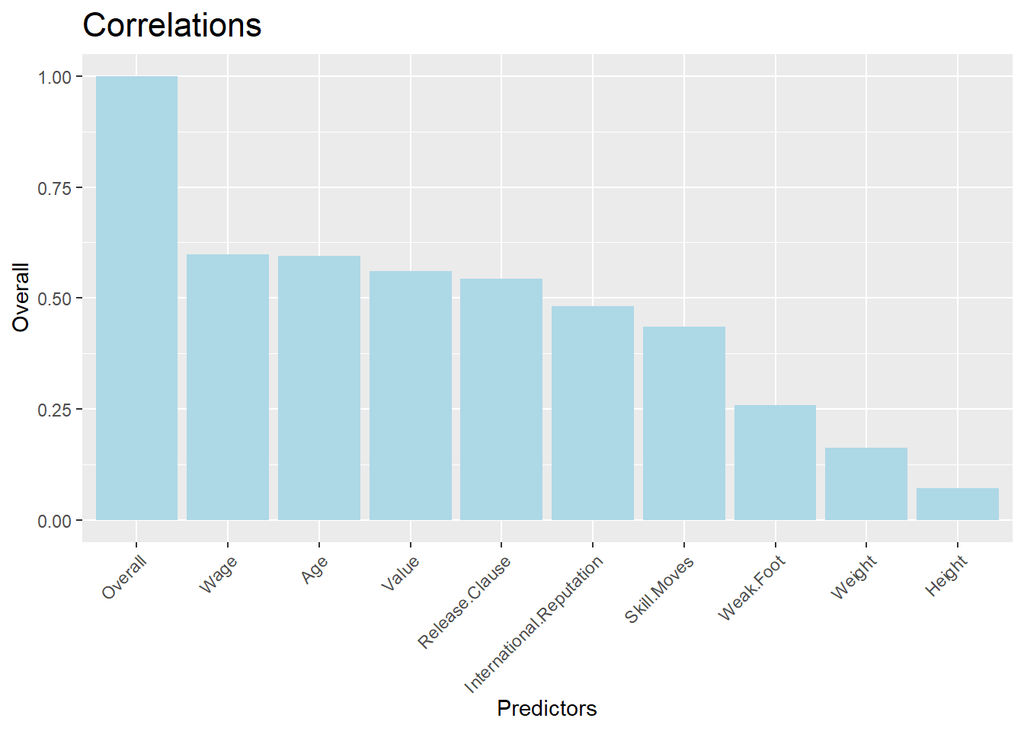

```r
library(leaps)

corr_ <- sort(cor(training[,c(-8)])["Overall",], decreasing = T)
corr=data.frame(corr_)
ggplot(corr,aes(x = row.names(corr), y = corr_)) +
  geom_bar(stat = "identity", fill = "lightblue") +
  scale_x_discrete(limits= row.names(corr)) +
  labs(x = "Predictors", y = "Overall", title = "Correlations") +
  theme(plot.title = element_text(hjust = 0, size = rel(1.5)),
        axis.text.x = element_text(angle = 45, hjust = 1))
```

For that reason we are going to compare them in order to compute the R-squared

```r
linFit <- lm(Overall ~ Age, data= training)
summary(linFit)
```

```
##
## Call:
## lm(formula = Overall ~ Age, data = training)
##
## Residuals:
##      Min       1Q   Median       3Q      Max
## -26.6173  -4.2584  -0.2883   3.7715  27.6818
##
## Coefficients:
##             Estimate Std. Error t value Pr(>|t|)
## (Intercept) 39.63042    0.35398   112.0   <2e-16 ***
## Age          1.02991    0.01504    68.5   <2e-16 ***
## ---
## Signif. codes:  0 '***' 0.001 '**' 0.01 '*' 0.05 '.' 0.1 ' ' 1
##
## Residual standard error: 6.443 on 8596 degrees of freedom
## Multiple R-squared:  0.3531, Adjusted R-squared:  0.353
## F-statistic:  4692 on 1 and 8596 DF,  p-value: < 2.2e-16
```

As we can see, the R-squared is around 0.4, which means is a weak-medium correlation ship, but it is significant.

Diagnosis:

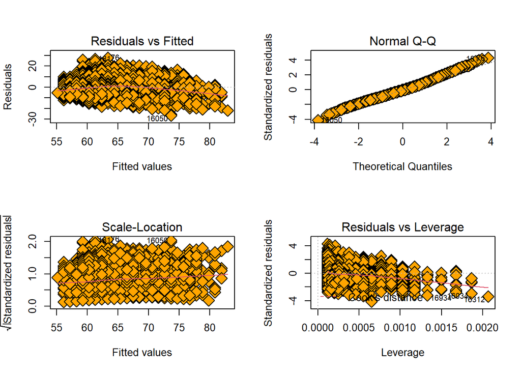

```r
par(mfrow=c(2,2))
plot(linFit, pch=23 ,bg='orange',cex=2)
```

We can see that in the Normal Q-Q we obtained a proportionally direct relationship. Meanwhile in others such as Scale-Location or Residuals vs Fitted there is not a clear relation ship. Lastly, the Residuals vs Leverage we can see a slightly proportionally inverse relation ship between the leverage and the standarizad residuals.

What would happen if we apply logs?

```r
linFit <- lm(log(Overall) ~ log(Age), data=training)
summary(linFit)
```

```
##
## Call:
## lm(formula = log(Overall) ~ log(Age), data = training)
##
## Residuals:
##      Min       1Q   Median       3Q      Max
## -0.44396 -0.06565  0.00008  0.06360  0.37245
##
## Coefficients:
##             Estimate Std. Error t value Pr(>|t|)
## (Intercept) 2.875972   0.017669  162.77   <2e-16 ***
## log(Age)    0.405587   0.005652   71.76   <2e-16 ***
## ---
## Signif. codes:  0 '***' 0.001 '**' 0.01 '*' 0.05 '.' 0.1 ' ' 1
##
## Residual standard error: 0.09926 on 8596 degrees of freedom
## Multiple R-squared:  0.3747, Adjusted R-squared:  0.3746
## F-statistic:  5150 on 1 and 8596 DF,  p-value: < 2.2e-16
```

We can appreciate that the R-squared increased a little bit.

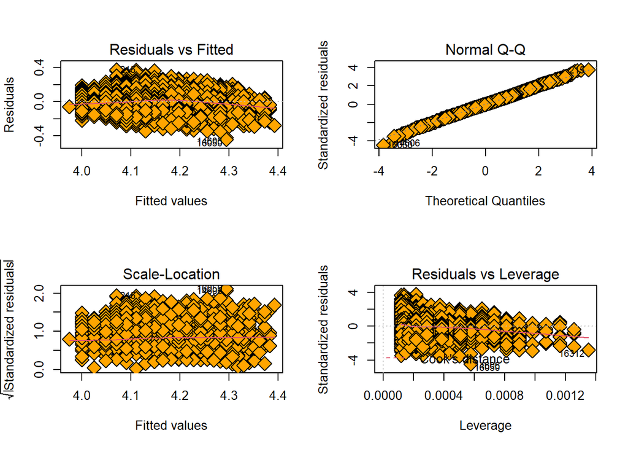

```r
par(mfrow=c(2,2))
plot(linFit, pch=23 ,bg='orange',cex=2)
```

We obtained almost the same result as before.

Predictions:

```r
pr.simple = exp(predict(linFit, newdata=testing))
cor(testing$Overall, pr.simple)^2
```

```
## [1] 0.3642715
```

We obtained around 0.4 of correlation, not a bad model using just one regressor, but it could be much better

## Multiple Regression

```r
linFit <- lm(Overall ~  Age + Value + Wage + International.Reputation + Weak.Foot + Skill.Moves + Height + Weight, data=training)
summary(linFit)
```

```
##
## Call:
## lm(formula = Overall ~ Age + Value + Wage + International.Reputation +
##     Weak.Foot + Skill.Moves + Height + Weight, data = training)
##
## Residuals:
##     Min      1Q  Median      3Q     Max
## -45.772  -3.003   0.214   3.265  16.014
##
## Coefficients:
##                            Estimate Std. Error t value Pr(>|t|)
## (Intercept)               1.730e+01  1.723e+00  10.038  < 2e-16 ***
## Age                       7.641e-01  1.303e-02  58.633  < 2e-16 ***
## Value                     2.864e-07  1.110e-08  25.793  < 2e-16 ***
## Wage                      5.980e-05  4.634e-06  12.903  < 2e-16 ***
## International.Reputation -5.016e-01  1.760e-01  -2.849  0.00439 **
## Weak.Foot                 6.754e-01  8.387e-02   8.053 9.13e-16 ***
## Skill.Moves               2.635e+00  8.313e-02  31.703  < 2e-16 ***
## Height                    8.449e-02  1.193e-02   7.081 1.54e-12 ***
## Weight                    5.945e-02  1.193e-02   4.982 6.42e-07 ***
## ---
## Signif. codes:  0 '***' 0.001 '**' 0.01 '*' 0.05 '.' 0.1 ' ' 1
##
## Residual standard error: 4.788 on 8589 degrees of freedom
## Multiple R-squared:  0.643,  Adjusted R-squared:  0.6427
## F-statistic:  1934 on 8 and 8589 DF,  p-value: < 2.2e-16
```

Prediction

```r
pr.multiple = exp(predict(linFit, newdata=testing))
cor(testing$Overall, pr.multiple)^2
```

```
## [1] 0.00414159
```

## Model Selection

```r
library(leaps)
exhaustive <- regsubsets(Overall ~ Age + Value + Wage + International.Reputation + Weak.Foot + Skill.Moves + Height + Weight, data=training)

summary(exhaustive)
```

```
## Subset selection object
## Call: regsubsets.formula(Overall ~ Age + Value + Wage + International.Reputation +
##     Weak.Foot + Skill.Moves + Height + Weight, data = training)
## 8 Variables  (and intercept)
##                          Forced in Forced out
## Age                          FALSE      FALSE
## Value                        FALSE      FALSE
## Wage                         FALSE      FALSE
## International.Reputation     FALSE      FALSE
## Weak.Foot                    FALSE      FALSE
## Skill.Moves                  FALSE      FALSE
## Height                       FALSE      FALSE
## Weight                       FALSE      FALSE
## 1 subsets of each size up to 8
## Selection Algorithm: exhaustive
##          Age Value Wage International.Reputation Weak.Foot Skill.Moves Height
## 1  ( 1 ) " " " "   "*"  " "                      " "       " "         " "
## 2  ( 1 ) "*" "*"   " "  " "                      " "       " "         " "
## 3  ( 1 ) "*" "*"   " "  " "                      " "       "*"         " "
## 4  ( 1 ) "*" "*"   " "  " "                      " "       "*"         "*"
## 5  ( 1 ) "*" "*"   "*"  " "                      " "       "*"         "*"
## 6  ( 1 ) "*" "*"   "*"  " "                      "*"       "*"         "*"
## 7  ( 1 ) "*" "*"   "*"  " "                      "*"       "*"         "*"
## 8  ( 1 ) "*" "*"   "*"  "*"                      "*"       "*"         "*"
##          Weight
## 1  ( 1 ) " "
## 2  ( 1 ) " "
## 3  ( 1 ) " "
## 4  ( 1 ) " "
## 5  ( 1 ) " "
## 6  ( 1 ) " "
## 7  ( 1 ) "*"
## 8  ( 1 ) "*"
```

Now we plot it

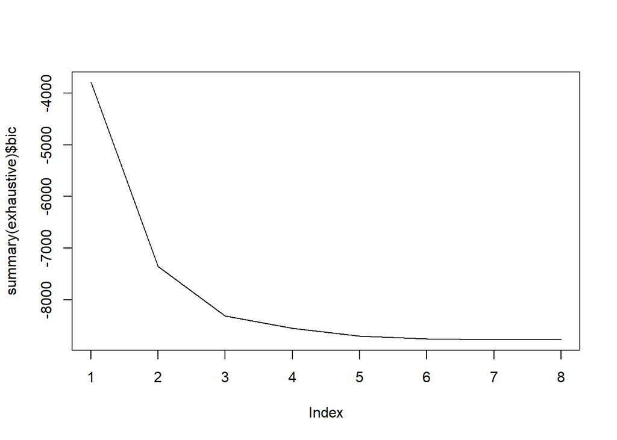

```r
plot(summary(exhaustive)$bic, type = 'l')
```

Alternatively

```r
library(olsrr)

model = Overall ~ Age + Value + Wage + International.Reputation + Weak.Foot + Skill.Moves + Height + Weight

linFit <- lm(model, data=training)

ols_step_all_possible(linFit) # All possible subset regressions: the number is exponential with p
```

```
##     Index N
## 3       1 1
## 1       2 1
## 2       3 1
## 4       4 1
## 6       5 1
## 5       6 1
## 8       7 1
## 7       8 1
## 9       9 2
## 10     10 2
## 13     11 2
## 24     12 2
## 11     13 2
## 19     14 2
```

[output cut: 753 more lines]

The best subset regression for each p: still exponential with p

```r
ols_step_best_subset(linFit)
```

```
##                                  Best Subsets Regression
## ------------------------------------------------------------------------------------------
## Model Index    Predictors
## ------------------------------------------------------------------------------------------
##      1         Wage
##      2         Age Value
##      3         Age Value Skill.Moves
##      4         Age Value Skill.Moves Height
##      5         Age Value Wage Skill.Moves Height
##      6         Age Value Wage Weak.Foot Skill.Moves Height
##      7         Age Value Wage Weak.Foot Skill.Moves Height Weight
##      8         Age Value Wage International.Reputation Weak.Foot Skill.Moves Height Weight
## ------------------------------------------------------------------------------------------
##
##                                                           Subsets Regression Summary
## ----------------------------------------------------------------------------------------------------------------------------------------------
##                        Adj.        Pred
## Model    R-Square    R-Square    R-Square      C(p)          AIC           SBIC          SBC           MSEP          FPE       HSP       APC
## ----------------------------------------------------------------------------------------------------------------------------------------------
##   1        0.3579      0.3578      0.3556    6855.1439    56375.4639    31973.2297    56396.6418    354248.5193    41.2109    0.0048    0.6424
##   2        0.5764      0.5763      0.5743    1599.5239    52800.7199    28399.6658    52828.9570    233718.6026    27.1924    0.0032    0.4239
##   3        0.6212      0.6211      0.6194     522.4511    51840.4777    27439.9527    51875.7742    208996.9283    24.3189    0.0028    0.3791
##   4        0.6321      0.6319      0.6302     263.9033    51593.0564    27192.7009    51635.4121    203044.8129    23.6291    0.0027    0.3684
##   5        0.6390      0.6388      0.6367      99.7799    51432.1647    27031.9762    51481.5797    199257.4682    23.1910    0.0027    0.3615
##   6        0.6416      0.6414      0.6393      37.6596    51370.4569    26970.3515    51426.9312    197809.5319    23.0252    0.0027    0.3589
##   7        0.6427      0.6424      0.6402      15.1192    51347.9490    26947.8836    51411.4825    197269.4576    22.9650    0.0027    0.3580
##   8        0.6430      0.6427      0.6404       9.0000    51341.8251    26941.7769    51412.4179    197106.1032    22.9486    0.0027    0.3578
## ----------------------------------------------------------------------------------------------------------------------------------------------
## AIC: Akaike Information Criteria
##  SBIC: Sawa's Bayesian Information Criteria
##  SBC: Schwarz Bayesian Criteria
##  MSEP: Estimated error of prediction, assuming multivariate normality
##  FPE: Final Prediction Error
##  HSP: Hocking's Sp
##  APC: Amemiya Prediction Criteria
```

Other practical methods when dimension (p/n) is too high

Forward based on AIC

```r
ols_step_forward_aic(linFit)
```

```
##
##                                     Selection Summary
## -----------------------------------------------------------------------------------------
## Variable                       AIC         Sum Sq         RSS         R-Sq      Adj. R-Sq
## -----------------------------------------------------------------------------------------
## Wage                        56375.464    197366.508    354166.117    0.35785      0.35778
## Age                         53294.915    304073.181    247459.444    0.55132      0.55122
## Skill.Moves                 52316.993    330728.536    220804.089    0.59965      0.59951
## Value                       51664.991    346901.012    204631.614    0.62898      0.62880
## Height                      51432.165    352414.217    199118.408    0.63897      0.63876
## Weak.Foot                   51370.457    353884.152    197648.473    0.64164      0.64139
## Weight                      51347.949    354446.733    197085.892    0.64266      0.64237
## International.Reputation    51341.825    354632.863    196899.763    0.64300      0.64266
## -----------------------------------------------------------------------------------------
```

Backward AIC

```r
ols_step_backward_aic(linFit) #
```

```
## [1] "No variables have been removed from the model."
```

stepwise AIC

```r
ols_step_both_aic(linFit)
```

```
##
##
##                                            Stepwise Summary
## -----------------------------------------------------------------------------------------------------
## Variable                     Method        AIC          RSS          Sum Sq       R-Sq      Adj. R-Sq
## -----------------------------------------------------------------------------------------------------
## Wage                        addition    56375.464    354166.117    197366.508    0.35785      0.35778
## Age                         addition    53294.915    247459.444    304073.181    0.55132      0.55122
## Skill.Moves                 addition    52316.993    220804.089    330728.536    0.59965      0.59951
## Value                       addition    51664.991    204631.614    346901.012    0.62898      0.62880
## Height                      addition    51432.165    199118.408    352414.217    0.63897      0.63876
## Weak.Foot                   addition    51370.457    197648.473    353884.152    0.64164      0.64139
## Weight                      addition    51347.949    197085.892    354446.733    0.64266      0.64237
## International.Reputation    addition    51341.825    196899.763    354632.863    0.64300      0.64266
## -----------------------------------------------------------------------------------------------------
```

```r
linFit <- lm(Overall ~ Age + Value + Wage + International.Reputation + Weak.Foot + Skill.Moves + Height + Weight, data=training)
summary(linFit)
```

```
##
## Call:
## lm(formula = Overall ~ Age + Value + Wage + International.Reputation +
##     Weak.Foot + Skill.Moves + Height + Weight, data = training)
##
## Residuals:
##     Min      1Q  Median      3Q     Max
## -45.772  -3.003   0.214   3.265  16.014
##
## Coefficients:
##                            Estimate Std. Error t value Pr(>|t|)
## (Intercept)               1.730e+01  1.723e+00  10.038  < 2e-16 ***
## Age                       7.641e-01  1.303e-02  58.633  < 2e-16 ***
## Value                     2.864e-07  1.110e-08  25.793  < 2e-16 ***
## Wage                      5.980e-05  4.634e-06  12.903  < 2e-16 ***
## International.Reputation -5.016e-01  1.760e-01  -2.849  0.00439 **
## Weak.Foot                 6.754e-01  8.387e-02   8.053 9.13e-16 ***
## Skill.Moves               2.635e+00  8.313e-02  31.703  < 2e-16 ***
## Height                    8.449e-02  1.193e-02   7.081 1.54e-12 ***
## Weight                    5.945e-02  1.193e-02   4.982 6.42e-07 ***
## ---
## Signif. codes:  0 '***' 0.001 '**' 0.01 '*' 0.05 '.' 0.1 ' ' 1
##
## Residual standard error: 4.788 on 8589 degrees of freedom
## Multiple R-squared:  0.643,  Adjusted R-squared:  0.6427
## F-statistic:  1934 on 8 and 8589 DF,  p-value: < 2.2e-16
```

We obtained a R2 close to 65%, which means it is a good model because it explains more or less in a reasonable way the variability of Overall.

## Predictions

```r
predictions <- exp(predict(linFit, newdata=testing))
cor(testing$Overall, predictions)^2
```

```
## [1] 0.00414159
```

```r
RMSE <- sqrt(mean((predictions - testing$Overall)^2))
RMSE
```

```
## [1] 1.423026e+52
```

It is an interesting result because it does not seems reasonable at all.

## A benchmark

We can compute the mean of the main numerical variable in the training set

```r
mean(training$Overall)
```

```
## [1] 63.40544
```

Which is equivalent to…

```r
benchFit <- lm(Overall ~ 1, data=training)
benchFit$coefficients
```

```
## (Intercept)
##    63.40544
```

```r
predictions <- predict(benchFit, newdata=testing)
RMSE <- sqrt(mean((predictions - testing$Overall)^2))
RMSE
```

```
## [1] 8.036018
```

## Statistical Learning Tools

Let’s use the caret package with CV

```r
ctrl <- trainControl(method = "repeatedcv",
                     number = 5, repeats = 1)
```

```r
linFit <- lm(Overall ~ Age + Value + Wage + International.Reputation + Weak.Foot + Skill.Moves + Height + Weight, data=training)

summary(linFit)
```

```
##
## Call:
## lm(formula = Overall ~ Age + Value + Wage + International.Reputation +
##     Weak.Foot + Skill.Moves + Height + Weight, data = training)
##
## Residuals:
##     Min      1Q  Median      3Q     Max
## -45.772  -3.003   0.214   3.265  16.014
##
## Coefficients:
##                            Estimate Std. Error t value Pr(>|t|)
## (Intercept)               1.730e+01  1.723e+00  10.038  < 2e-16 ***
## Age                       7.641e-01  1.303e-02  58.633  < 2e-16 ***
## Value                     2.864e-07  1.110e-08  25.793  < 2e-16 ***
## Wage                      5.980e-05  4.634e-06  12.903  < 2e-16 ***
## International.Reputation -5.016e-01  1.760e-01  -2.849  0.00439 **
## Weak.Foot                 6.754e-01  8.387e-02   8.053 9.13e-16 ***
## Skill.Moves               2.635e+00  8.313e-02  31.703  < 2e-16 ***
## Height                    8.449e-02  1.193e-02   7.081 1.54e-12 ***
## Weight                    5.945e-02  1.193e-02   4.982 6.42e-07 ***
## ---
## Signif. codes:  0 '***' 0.001 '**' 0.01 '*' 0.05 '.' 0.1 ' ' 1
##
## Residual standard error: 4.788 on 8589 degrees of freedom
## Multiple R-squared:  0.643,  Adjusted R-squared:  0.6427
## F-statistic:  1934 on 8 and 8589 DF,  p-value: < 2.2e-16
```

Consider the following model: It is important to mention that we could include the categorical variables such as Real.Face. I will not introduce some variables such as the preferred foot because I consider it does not sum anything to our model because it is insignificant if a player prefers to play with its right or left foot.

```r
ModelS = Overall ~ Real.Face + Age + Wage + International.Reputation*Value + Weak.Foot + Skill.Moves + Height + Weight


ModelF = Overall ~ Age*Skill.Moves + Wage*International.Reputation + Value + Weak.Foot + Weight/Height^2
```

**NOTE:** Most of the models applied have the same plot and characteristics, even thought I have applied two distinct models in order to search some differences.

## Linear Regression

```r
lm_tune <- train(ModelS, data = training,
                 method = "lm",
                 preProc=c('scale', 'center'),
                 trControl = ctrl)
lm_tune
```

```
## Linear Regression
##
## 8598 samples
##    9 predictor
##
## Pre-processing: scaled (10), centered (10)
## Resampling: Cross-Validated (5 fold, repeated 1 times)
## Summary of sample sizes: 6877, 6878, 6879, 6879, 6879
## Resampling results:
##
##   RMSE      Rsquared   MAE
##   4.418245  0.6963677  3.483255
##
## Tuning parameter 'intercept' was held constant at a value of TRUE
```

From this point we will start creating a lot of models so it is a good idea to create a data frame which contains all the predictors.

```r
test_results <- data.frame(Overall = testing$Overall)
```

Now we must predict

```r
test_results$lm <- predict(lm_tune, testing)
postResample(pred = test_results$lm,  obs = test_results$Overall)
```

```
##      RMSE  Rsquared       MAE
## 4.5460680 0.6800771 3.5439959
```

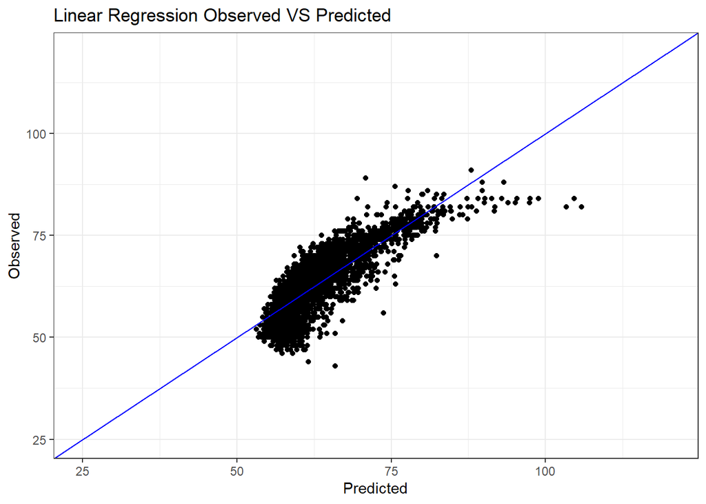

```r
qplot(test_results$lm, test_results$Overall) +
  labs(title="Linear Regression Observed VS Predicted", x="Predicted", y="Observed") +
  lims(x = c(25, 120), y = c(25, 120)) +
  geom_abline(intercept = 0, slope = 1, colour = "blue") +
  theme_bw()
```

We can see that the result are quite good and there is a very low bias because most of the points are together in the straight line and also there is a very low variance because most of the points are together (except some at the most right part). Also the points observed and predicted forms something similar to a straight line (x = y) with some points scattered but still a very good model. So that is something good because at the end of the day we want to avoid high bias and high variability because it affects our predictions and makes worse our model.

Anyways, we could try with others models in order to compare and see if there is another one better

## Overfitted linear regression

We start by training our model

```r
alm_tune <- train(ModelS, data = training,
                  method = "lm",
                  preProc=c('scale', 'center'),
                  trControl = ctrl)
```

And now predict

```r
test_results$alm <- predict(alm_tune, testing)
postResample(pred = test_results$alm,  obs = test_results$Overall)
```

```
##      RMSE  Rsquared       MAE
## 4.5460680 0.6800771 3.5439959
```

Visualization

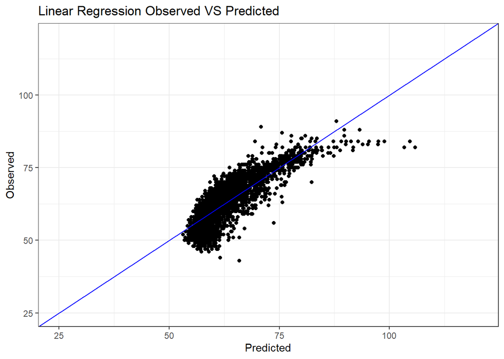

```r
qplot(test_results$alm, test_results$Overall) +
  labs(title="Linear Regression Observed VS Predicted", x="Predicted", y="Observed") +
  lims(x = c(25,120), y = c(25,120)) +
  geom_abline(intercept = 0, slope = 1, colour = "blue") +
  theme_bw()
```

Visually it looks quite similar to the previous plot without the over fitted linear regression, so probably this model it is not the most recommended because it is more time demanding and PC demanding just to obtain practically the same result. However it might be taken into consideration that because there are too many data, we cannot actually see how the points are distributed.

## Forward regression

We start by training our model

```r
for_tune <- train(ModelS, data = training,
                  method = "leapForward",
                  preProc=c('scale', 'center'),
                  tuneGrid = expand.grid(nvmax = 4:10),
                  trControl = ctrl)

for_tune
```

```
## Linear Regression with Forward Selection
##
## 8598 samples
##    9 predictor
##
## Pre-processing: scaled (10), centered (10)
## Resampling: Cross-Validated (5 fold, repeated 1 times)
## Summary of sample sizes: 6879, 6878, 6877, 6879, 6879
## Resampling results across tuning parameters:
##
##   nvmax  RMSE      Rsquared   MAE
##    4     4.825225  0.6384199  3.754355
##    5     4.543718  0.6781438  3.551141
##    6     4.493807  0.6851952  3.528080
##    7     4.480670  0.6870171  3.513039
##    8     4.468172  0.6887535  3.509417
##    9     4.446172  0.6918357  3.493545
##   10     4.436285  0.6932255  3.486634
##
## RMSE was used to select the optimal model using the smallest value.
## The final value used for the model was nvmax = 10.
```

Plot it

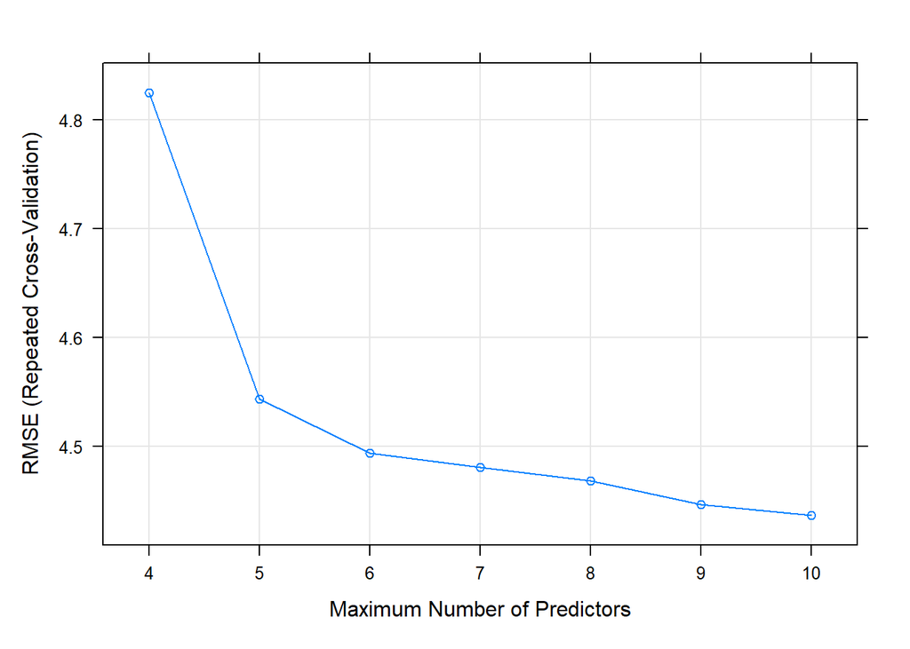

```r
plot(for_tune)
```

```r
coef(for_tune$finalModel, for_tune$bestTune$nvmax)
```

```
##                    (Intercept)                     Real.Face1
##                     63.4054431                      0.4615749
##                            Age                           Wage
##                      3.1866773                      1.1429244
##       International.Reputation                          Value
##                      0.6072444                      6.5216244
##                      Weak.Foot                    Skill.Moves
##                      0.3796132                      1.6359914
##                         Height                         Weight
##                      0.3963256                      0.4290168
## International.Reputation:Value
##                     -4.9238557
```

Predict

```r
test_results$frw <- predict(for_tune, testing)
postResample(pred = test_results$frw,  obs = test_results$Overall)
```

```
##      RMSE  Rsquared       MAE
## 4.5460680 0.6800771 3.5439959
```

Again we obtain a Rsquared of 0.69 which is a good model because it is almost 70% of the variability of Overall explained. However it is still identical to the previous ones (it is true that we are using the same model which I consider the model which estimates the best the response variable)

Visualization

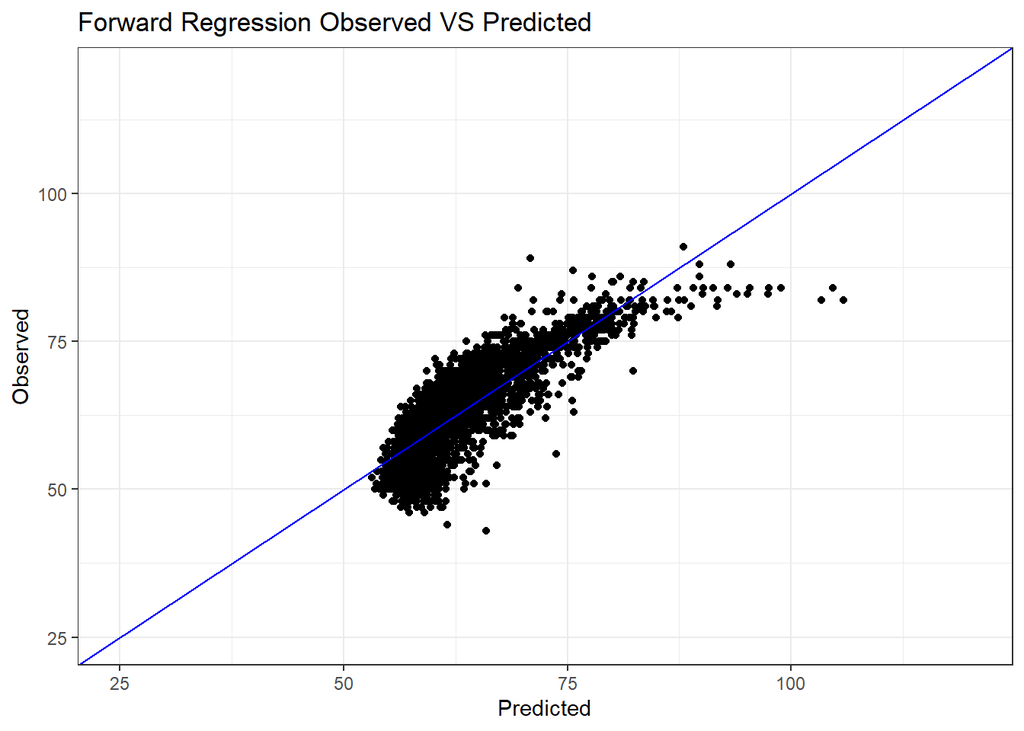

```r
qplot(test_results$frw, test_results$Overall) +
  labs(title="Forward Regression Observed VS Predicted", x="Predicted", y="Observed") +
  lims(x = c(25,120), y = c(25,120)) +
  geom_abline(intercept = 0, slope = 1, colour = "blue") +
  theme_bw()
```

Once again, we obtain a plot quite similar to the previous ones, where the bias and the variability are very low and there are some outliers at the right.

## Backward regression

Again, we start training the model, but this time I will apply the modelF just to see if there is any important difference

```r
back_tune <- train(ModelF, data = training,
                   method = "leapBackward",
                   preProc=c('scale', 'center'),
                   tuneGrid = expand.grid(nvmax = 4:10),
                   trControl = ctrl)
back_tune
```

```
## Linear Regression with Backwards Selection
##
## 8598 samples
##    8 predictor
##
## Pre-processing: scaled (10), centered (10)
## Resampling: Cross-Validated (5 fold, repeated 1 times)
## Summary of sample sizes: 6877, 6879, 6878, 6879, 6879
## Resampling results across tuning parameters:
##
##   nvmax  RMSE      Rsquared   MAE
##    4     4.842574  0.6347637  3.787671
##    5     4.613475  0.6684915  3.613248
##    6     4.554807  0.6768661  3.582260
##    7     4.514159  0.6826636  3.550605
##    8     4.479765  0.6874472  3.503859
##    9     4.466158  0.6892942  3.491873
##   10     4.463872  0.6896136  3.492346
##
## RMSE was used to select the optimal model using the smallest value.
## The final value used for the model was nvmax = 10.
```

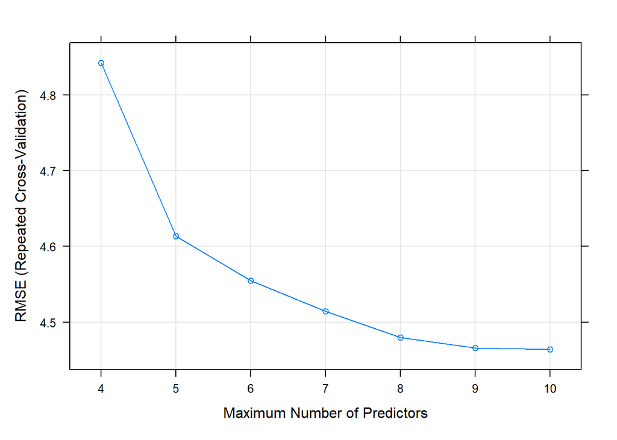

```r
plot(back_tune)
```

```r
coef(back_tune$finalModel, back_tune$bestTune$nvmax)
```

```
##                   (Intercept)                           Age
##                    63.4054431                     4.7214202
##                   Skill.Moves                          Wage
##                     4.4954237                     5.3243257
##      International.Reputation                         Value
##                     1.0367220                     2.1573758
##                     Weak.Foot                        Weight
##                     0.3759063                    -0.7437793
##               Age:Skill.Moves Wage:International.Reputation
##                    -3.5430654                    -4.7850824
##                 Weight:Height
##                     1.5115491
```

We predict

```r
test_results$bw <- predict(back_tune, testing)
postResample(pred = test_results$bw,  obs = test_results$Overall)
```

```
##      RMSE  Rsquared       MAE
## 4.5124948 0.6847633 3.5376468
```

Now we obtained a 0.69 of Rsquared, so we might think it could be due to the model or due to the type of regression tool applied, for that reason I will plot it and after that I will apply this regression tool for ModelS

Visualize

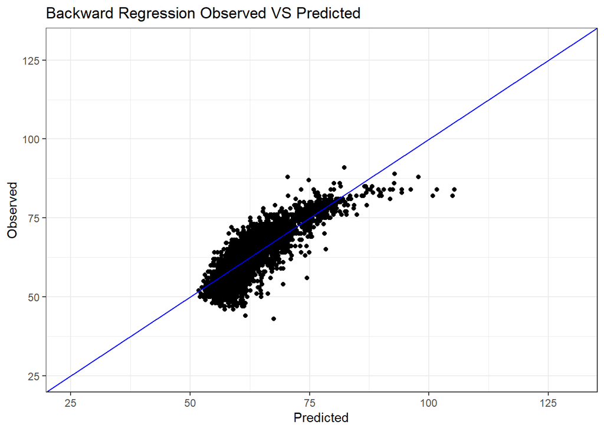

```r
qplot(test_results$bw, test_results$Overall) +
  labs(title="Backward Regression Observed VS Predicted", x="Predicted", y="Observed") +
  lims(x = c(25, 130), y = c(25, 130)) +
  geom_abline(intercept = 0, slope = 1, colour = "blue") +
  theme_bw()
```

Lets do the same for ModelS just to see if its due to the model

```r
back_tune <- train(ModelS, data = training,
                   method = "leapBackward",
                   preProc=c('scale', 'center'),
                   tuneGrid = expand.grid(nvmax = 4:10),
                   trControl = ctrl)
back_tune
```

```
## Linear Regression with Backwards Selection
##
## 8598 samples
##    9 predictor
##
## Pre-processing: scaled (10), centered (10)
## Resampling: Cross-Validated (5 fold, repeated 1 times)
## Summary of sample sizes: 6879, 6878, 6878, 6877, 6880
## Resampling results across tuning parameters:
##
##   nvmax  RMSE      Rsquared   MAE
##    4     4.633362  0.6660782  3.634897
##    5     4.541060  0.6789724  3.551180
##    6     4.490944  0.6859880  3.524040
##    7     4.468275  0.6891097  3.512073
##    8     4.448445  0.6917841  3.502446
##    9     4.432743  0.6939682  3.487460
##   10     4.424714  0.6950849  3.485575
##
## RMSE was used to select the optimal model using the smallest value.
## The final value used for the model was nvmax = 10.
```

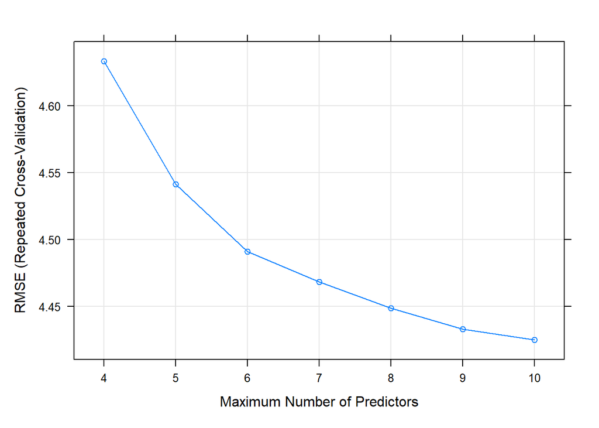

```r
plot(back_tune)
```

```r
coef(back_tune$finalModel, back_tune$bestTune$nvmax)
```

```
##                    (Intercept)                     Real.Face1
##                     63.4054431                      0.4615749
##                            Age                           Wage
##                      3.1866773                      1.1429244
##       International.Reputation                          Value
##                      0.6072444                      6.5216244
##                      Weak.Foot                    Skill.Moves
##                      0.3796132                      1.6359914
##                         Height                         Weight
##                      0.3963256                      0.4290168
## International.Reputation:Value
##                     -4.9238557
```

```r
test_results$bw <- predict(back_tune, testing)
postResample(pred = test_results$bw,  obs = test_results$Overall)
```

```
##      RMSE  Rsquared       MAE
## 4.5460680 0.6800771 3.5439959
```

# Ridge Regression

```r
# X matrix
X = model.matrix(ModelF, data=training)[,-1]  # skip column of ones

# y variable
y = log(training$Overall)
```

Now we need to define a grid for the penalty hyper-parameter lambda

```r
grid = seq(0, .1, length = 100)  # a 100-size grid for lambda (rho in slides)
```

Estimate the ridge regression for all the penalties defined in the grid. The algorithm is extremely fast

```r
ridge.mod = glmnet(X, y, alpha=0, lambda=grid)  # alpha=0 for ridge regression
```

Remember ridge regression is shrinking only beta’s associated with variables, not β0

For each of the 100 values of rho (lambda), there are 10 estimated parameters

```r
dim(coef(ridge.mod))
```

```
## [1]  11 100
```

```r
coef(ridge.mod)
```

[output not shown]

[output cut: 354 more lines]

```
## Age:Skill.Moves               -3.394977e-04 -7.051590e-04 -1.344084e-03
## Wage:International.Reputation -8.833562e-07 -9.708897e-07 -1.075037e-06
## Weight:Height                  8.519296e-06  9.478924e-06  1.110056e-05
##
## (Intercept)                    3.492760e+00
## Age                            1.711192e-02
## Skill.Moves                    1.041853e-01
## Wage                           3.709647e-06
## International.Reputation       3.337050e-02
## Value                          3.775886e-09
## Weak.Foot                      9.706199e-03
## Weight                        -1.647333e-03
## Age:Skill.Moves               -2.730262e-03
## Wage:International.Reputation -1.197054e-06
## Weight:Height                  1.440888e-05
```

By plotting the solution path

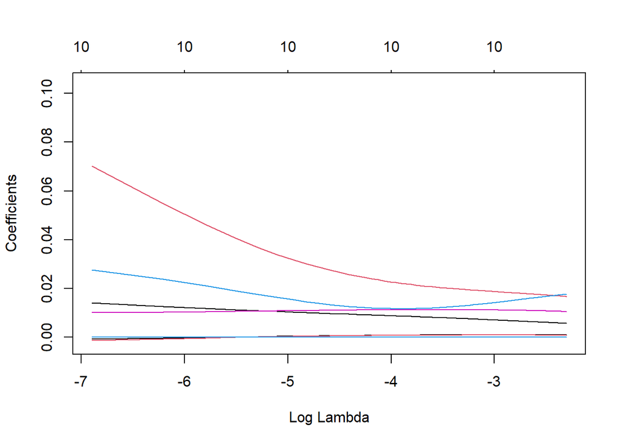

```r
plot(ridge.mod, xvar="lambda")
```

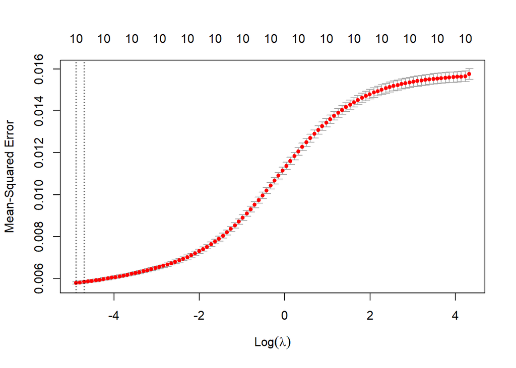

```r
ridge.cv = cv.glmnet(X, y, type.measure="mse", alpha=0)
plot(ridge.cv)
```

The lowest point in the curve indicates the optimal lambda: the log value of lambda that best minimised the error in cross-validation

So we are going to compute the optimal landa

```r
opt.lambda <- ridge.cv$lambda.min
opt.lambda
```

```
## [1] 0.007528599
```

We find out that the value of lambda should be 0.007

In order to estimate the betas and lambdas, we could apply the following method (1se):

```r
lambda.index <- which(ridge.cv$lambda == ridge.cv$lambda.1se)
beta.ridge <- ridge.cv$glmnet.fit$beta[, lambda.index]
beta.ridge
```

```
##                           Age                   Skill.Moves
##                  9.874348e-03                  2.865188e-02
##                          Wage      International.Reputation
##                  1.979532e-06                  1.387830e-02
##                         Value                     Weak.Foot
##                  4.061983e-09                  1.095431e-02
##                        Weight               Age:Skill.Moves
##                  4.697678e-04                  4.300902e-04
## Wage:International.Reputation                 Weight:Height
##                 -5.643402e-07                  6.346240e-06
```

Prediction

```r
X.test = model.matrix(ModelF, data=testing)[,-1]  # skip column of ones

ridge.pred = predict(ridge.cv$glmnet.fit, s=opt.lambda, newx=X.test)
```

To visualize the performance, we can use the postResample function in caret

```r
y.test = log(testing$Overall)

postResample(pred = ridge.pred,  obs = y.test)
```

```
##       RMSE   Rsquared        MAE
## 0.07702468 0.62919231 0.06065645
```

And using Caret…

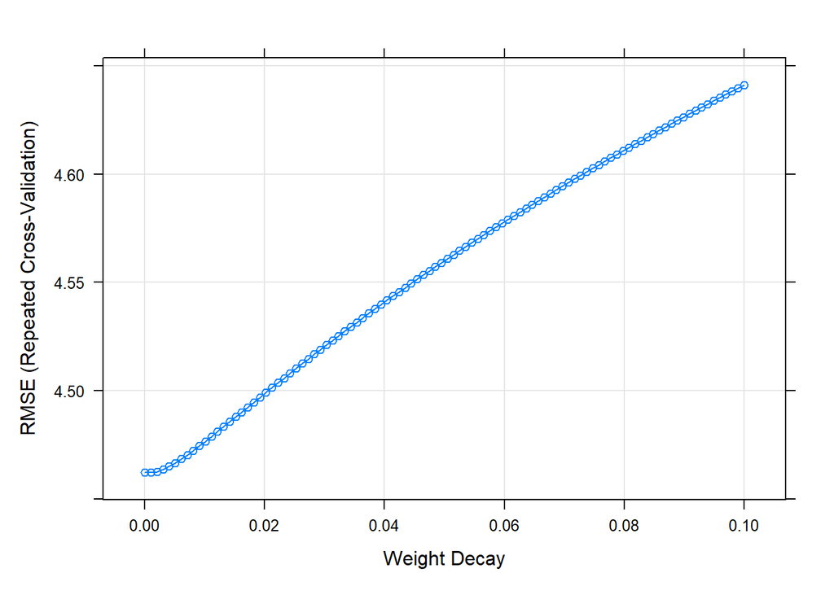

```r
library(elasticnet)
# the grid for lambda
ridge_grid <- expand.grid(lambda = seq(0, .1, length = 100))

# train
ridge_tune <- train(ModelF, data = training,
                    method='ridge',
                    preProc=c('scale','center'),
                    tuneGrid = ridge_grid,
                    trControl=ctrl)
plot(ridge_tune)
```

```r
# the best tune
ridge_tune$bestTune
```

```
##        lambda
## 2 0.001010101
```

We obtain that the optimal value for lambda.

```r
# prediction
test_results$ridge <- predict(ridge_tune, testing)

postResample(pred = test_results$ridge,  obs = test_results$Overall)
```

```
##      RMSE  Rsquared       MAE
## 4.5130065 0.6846997 3.5400526
```

Again, we obtain similar results and the rsquared once again is 0.69 which is decent.

## The Lasso

Lets compute it directly with Caret

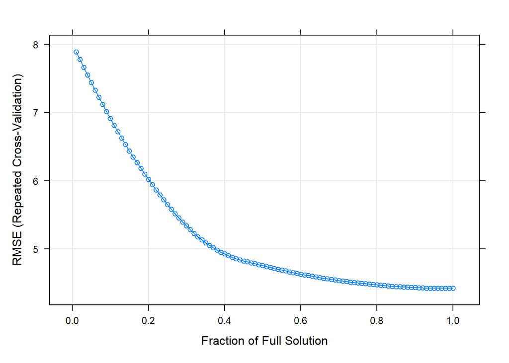

```r
lasso_grid <- expand.grid(fraction = seq(.01, 1, length = 100))

lasso_tune <- train(ModelS, data = training,
                    method='lasso',
                    preProc=c('scale','center'),
                    tuneGrid = lasso_grid,
                    trControl=ctrl)
plot(lasso_tune)
```

```r
lasso_tune$bestTune
```

```
##    fraction
## 99     0.99
```

```r
test_results$lasso <- predict(lasso_tune, testing)
postResample(pred = test_results$lasso,  obs = test_results$Overall)
```

```
##      RMSE  Rsquared       MAE
## 4.5442242 0.6802959 3.5453795
```

Some insights that we could obtain from this tool is that we obtain a good model that it looks it is not neither under fitted or over fitted because the rsquared is approximately 0.7 so as previous models, is a good model and regression tool but we would like to improve a little bit more how the predictors explains our response variable (Rsquared)

## Elastic Net

Lets start by cheking the names for the hyper-parameters

```r
modelLookup('glmnet')
```

```
##    model parameter                    label forReg forClass probModel
## 1 glmnet     alpha        Mixing Percentage   TRUE     TRUE      TRUE
## 2 glmnet    lambda Regularization Parameter   TRUE     TRUE      TRUE
```

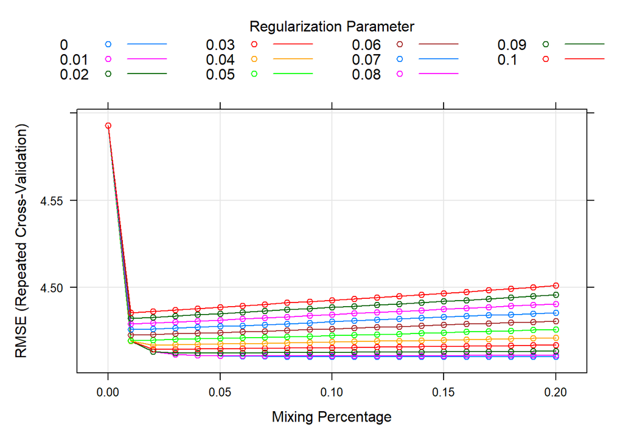

```r
elastic_grid = expand.grid(alpha = seq(0, .2, 0.01), lambda = seq(0, .1, 0.01))

glmnet_tune <- train(ModelF, data = training,
                     method='glmnet',
                     preProc=c('scale','center'),
                     tuneGrid = elastic_grid,
                     trControl=ctrl)

plot(glmnet_tune)
```

We can see in the graph that we obtain lines that are very close one to the other.

```r
glmnet_tune$bestTune
```

```
##     alpha lambda
## 210  0.19      0
```

# Machine Learning Tools

## KNN

Lets have a look on the hyper parameters names

```r
modelLookup('kknn')
```

```
##   model parameter           label forReg forClass probModel
## 1  kknn      kmax Max. #Neighbors   TRUE     TRUE      TRUE
## 2  kknn  distance        Distance   TRUE     TRUE      TRUE
## 3  kknn    kernel          Kernel   TRUE     TRUE      TRUE
```

3 hyper-parameters: kmax, distance, kernel # kmax: number of neighbors considered # distance: parameter of Minkowski distance (p in Lp) # kernel: “rectangular” (standard unweighted knn), “triangular”, “epanechnikov” (or beta(2,2)), “biweight” (or beta(3,3)), “tri- weight” (or beta(4,4)), “cos”, “inv”, “gaussian”, “rank” and “optimal”.

Now we should train. Because Machine Learning models are non-linear we can use simpler formulas in order to make predictions

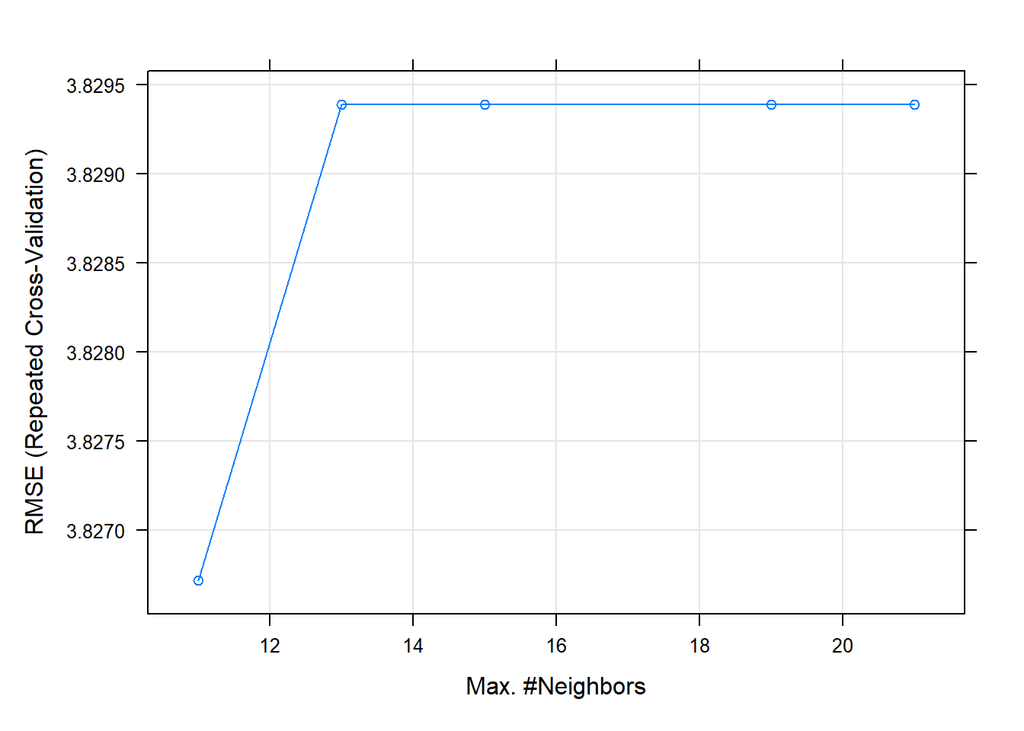

```r
library(kknn)
library(igraph)

knn_tune <- train(ModelS,
                  data = training,
                  method = "kknn",
                  preProc=c('scale','center'),
                  tuneGrid = data.frame(kmax=c(11,13,15,19,21),distance=2,kernel='optimal'),
                  trControl = ctrl)
plot(knn_tune)
```

This process is quite PC-resource demanding.

```r
test_results$knn <- predict(knn_tune, testing)

postResample(pred = test_results$knn,  obs = test_results$Overall)
```

```
##      RMSE  Rsquared       MAE
## 3.8342692 0.7743154 2.9387530
```

## Random Forest

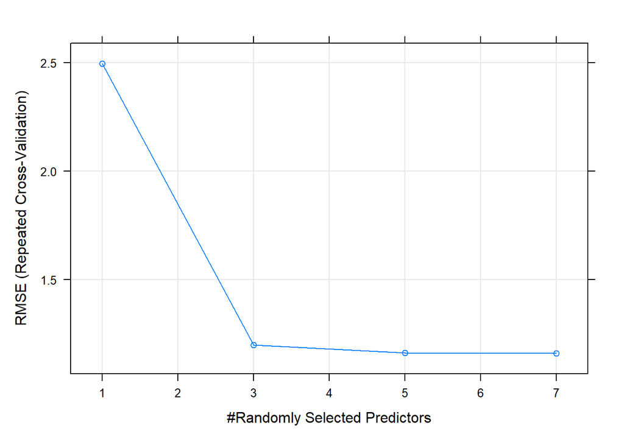

```r
rf_tune <- train(ModelS,
                 data = training,
                 method = "rf",
                 preProc=c('scale','center'),
                 trControl = ctrl,
                 ntree = 100,
                 tuneGrid = data.frame(mtry=c(1,3,5,7)),
                 importance = TRUE)

plot(rf_tune)
```

```r
test_results$rf <- predict(rf_tune, testing)

postResample(pred = test_results$rf,  obs = test_results$Overall)
```

```
##      RMSE  Rsquared       MAE
## 1.3828510 0.9704013 0.7249849
```

At the moment the random forest tool is which explains and predicts our data in the best way.

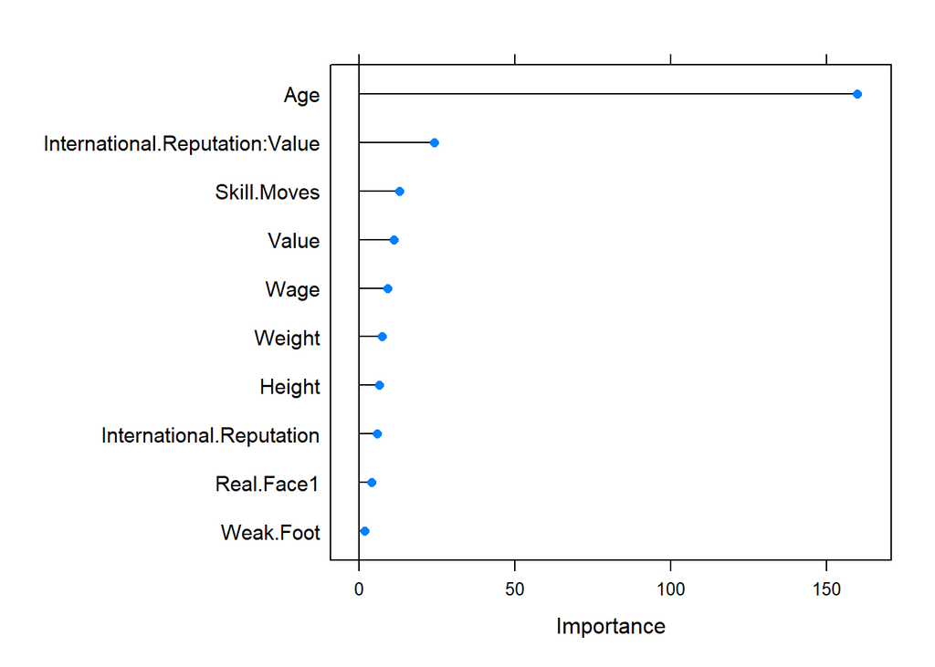

```r
plot(varImp(rf_tune, scale = F), scales = list(y = list(cex = .95)))
```

As we can see, the most important variable is the Age, which is extremely significant compared to the other variables. For that reason we could say that the predictions are based on just one variable which is the most important predictor in order to predict our response variable.

## Gradient Boosting

```r
xgb_tune <- train(ModelS,
                  data = training,
                  method = "xgbTree",
                  preProc=c('scale','center'),
                  objective="reg:squarederror",
                  trControl = ctrl,
                  tuneGrid = expand.grid(nrounds = c(500,1000), max_depth = c(5,6,7), eta = c(0.01, 0.1, 1),
                                         gamma = c(1, 2, 3), colsample_bytree = c(1, 2),
                                         min_child_weight = c(1), subsample = c(0.2,0.5,0.8)))
```

[output not shown]

[output cut: 350 more lines]

[output not shown]

```r
test_results$xgb <- predict(xgb_tune, testing)

postResample(pred = test_results$xgb,  obs = test_results$Overall)
```

```
##      RMSE  Rsquared       MAE
## 1.3104749 0.9734071 0.7070312
```

## Ensemble

Let’s summarize the MAE for all the tools

```r
apply(test_results[-1], 2, function(x) mean(abs(x - test_results$Overall)))
```

```
##        lm       alm       frw        bw     ridge     lasso       knn        rf
## 3.5439959 3.5439959 3.5439959 3.5439959 3.5400526 3.5453795 2.9387530 0.7249849
##       xgb
## 0.7070312
```

```r
# Combination
test_results$comb = (test_results$alm + test_results$knn + test_results$rf)/3

postResample(pred = test_results$comb,  obs = test_results$Overall)
```

```
##      RMSE  Rsquared       MAE
## 2.8172479 0.8845751 2.1553037
```

## Prediction Interval

**NOTE:** I decided to do not use this tool because I was having some troubles in order to execute it, so I decided to just write the code with # in order to show how it should be applied this method because I consider it is important to show the maximum number of tools as possible.

```r
# y = exp(test_results$Overall)
# error = y-yhat
# hist(error, col="lightblue")

# We will use the first 100 players in order to compute the noise
# noise = error[1:100]

# Lets set a 90% confidence in the prediction intervals
# lwr = yhat[101:length(yhat)] + quantile(noise,0.05, na.rm=T)
# upr = yhat[101:length(yhat)] + quantile(noise,0.95, na.rm=T)

# predictions = data.frame(real=y[101:length(y)], fit=yhat[101:length(yhat)], lwr=lwr, upr=upr)

# predictions = predictions %>% mutate(out=factor(if_else(real<lwr | real>upr,1,0)))

# We can compute how many observations are out of the intervals
# mean(predictions$out==1)

# We can finally plot it
# ggplot(predictions, aes(x=fit, y=real))+
  # geom_point(aes(color=out)) + theme(legend.position="none") +
  # xlim(20000, 1000000) + ylim(20000, 1000000)+
  # geom_ribbon(data=predictions,aes(ymin=lwr,ymax=upr),alpha=0.3) +
  # labs(title = "Prediction intervals", x = "prediction",y="real price")
```

## Final Predictions

```r
yhat = exp(test_results$comb)

head(yhat)
```

```
## [1] 3.707436e+38 3.758604e+35 5.786076e+37 5.726949e+37 2.228724e+36
## [6] 4.064332e+37
```

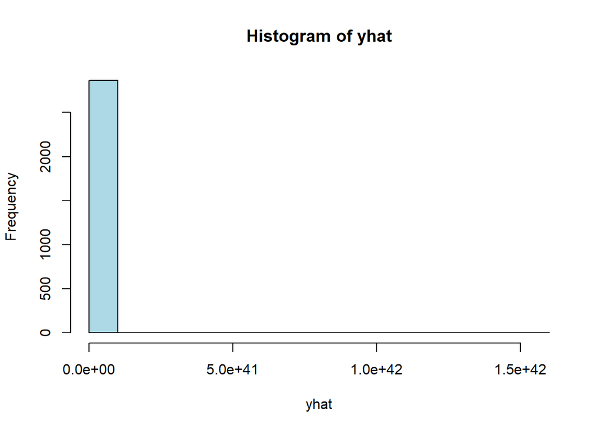

```r
hist(yhat, col="lightblue")
```

## Conclusion for Regression

After applying the different regression tools and try two different models in order to see which one would bring us the most rsquared (and in general, the best regression model and tool), we tried different such as backwards or lineal regressions, most of them gave us an rsquared around 0.7. However, there were two tools that standed out compared to the rest of the tools employed, which were the random forests and the XGB tools, both of them game us an rsquared of 0.97, so it is clear that they were the most effective and reliable tools. Furthermore, we created two different models (modelS and modelF) in order to apply the different tools into this two models. We even compared by applying one regression tool, which was Backwards Regression, in which we obtained the rsquared and the plot for both models and noticed that they were basically equal, there was almost not difference between choosing one or other model.

In this regression part we obtained created and obtained good models that can predict very well the data proposed by applying different regression tools.

# Final Conclusion

After completing this Homework, I had applied a lot of different supervised learning tools for classification and regression. We had work with bivariable classes and multinomial classes in classification and also to obtain optimal hyper parameters and tresholds. Classification has been very useful in order to understand the importance of how categorical variables can be predict depending on other variables without necessary been highly correlated. It was very interesting to focus on just one categorical variable and apply methods such as LDA or QDA which gives us useful information about the data set and in order to predict. Also probably the best classification tool for which I obtained the best model was either random forest or XGB boosting, those two was pretty good in order to obtain the best accuracy with the lowest cost as possible. We also did other classification tools such as GBM boosting which was more friendly in terms of Pc resources. Basically, we applied different tools where each have its advantages and disadvantages, and depending on the context, one or other would be more useful.

For regression it was also quite interesting to try to predict by training a model and testing it in order to obtain the best model that represent in the best way the data. Also for regression it was quite interesting to try to produce a own model (modelS or modelF) just by applying feature engineering in order to find the correlations between variables in order to obtain the best model as possible and trying different tools in order to see aspects such as the Rsquared in order to see which one have the highest efficiency, in where we obtained models with a Rsquared around 0.7. But we also obtained by applying other regression tools models with a rsquared higher that 0.95, which is almost a perfect regression (some examples could be RF or XGB), which it is true that both are quite time and PC demanding but it is worth it in order to obtain a reliable model.

It is important to mention the data set, which, as we can suppose it is essential to have a big data set in order to obtain realistic results, which I consider that has been my case, I choose a huge data set in order to predict and obtain the best possible models. For the previous home work that was about unsupervised learning tools I also choose this data set because I consider it is the enough diverse and big to can study it in different ways, by applying either supervised or unsupervised learning tools. As I recommended in my work, it would be interesting to apply supervised learning tools, and I finally did it.

I decided to make most of the tools available because I wanted to learn as much as possible about supervised learning tools and in order to have the knowledge in order to be able to apply it by my self.